# GDP Analysis v1.8

## Assignment GDP Analysis

**Author:** Anish Mahapatra **Email-id:** anishmahapatra01@gmail.com

##### Upgrad Module 09 - Assignment: GDP Analysis

The purpose of this the overall GDP Analysis is to help identify areas to focus on, that will foster economic development for the respective states. This will be done by analyzing the GDP.

**GDP:** Monetary value of final goods and services produced by a country/state in a given period of time. It mostly consists of the following three sectors:

- Primary sector (agriculture)
- Secondary sector (industry)
- Tertiary sector (services)

In the **first part** of the analysis, the following steps will be taken care of:

- the GSDP of Indian States - both total and per capita will be analyzed
- The States will be divided into 4 cases on the basis of GSDP analysis
- Post categorizaion, analysis will be done to identify the sectors that contribute the most to GDP

In the **second part** of the analysis, we shall analyze whether GDP per capita is related to dropout rates in schools and colleges.

Let's go!

## Data Loading - Data1, GSDP, Data2

```python
#Importing the required modules and packages

import matplotlib.pyplot as plt; plt.rcdefaults()
from matplotlib.ticker import StrMethodFormatter
%matplotlib inline
import seaborn as sns
import pandas as pd
import numpy as np
import glob, os

pd.set_option('display.max_columns', 500)

import warnings
warnings.filterwarnings("ignore")
```

### State Files

```python
# Filling in the path variable to pick up the .csv files from the 'Data Folder'
# This is just the GSDP data
path = './Data/*.csv'

# Reading all the paths to the csv files and initializing an empty list
all_files = glob.glob(path)
allFilesList = []

# For loop to ingest all csv files, transpose the data and append the same onto a master datatset

for filename in all_files:
    # Reading each file into a pandas dataframe with 'latin' encoding
    df = pd.read_csv(filename, encoding = 'latin', index_col = None, header = 0)

    # Selecting relevant columns from all the State Files
    df = df[['S.No.', 'Item', '2014-15']]

    # Transposing the data using transpose() function
    df = df.transpose()

    # Removing the first row that contains the headers from df
    new_header = df.iloc[0]
    df = df[1:]

    # Making first row as column
    df.columns = new_header

    # Getting the name of the state to add it as a new column in the master dataset
    df.loc[:, 'State'] = filename.split('\\')[-1].split('.')[0]
    allFilesList.append(df)

# Concatenating the data into the master dataset called dfGSDP
dfStateGDP = pd.concat(allFilesList, axis = 0, ignore_index = True)
```

```python
# Sense check of master dataset of State's GDP
dfStateGDP.head()
```

| S.No. | 1 | 1.1 | 1.2 | 1.3 | 1.4 | 2 | Total | 3 | 4 | 5 | Total | 6 | 6.1 | 6.2 | 7 | 7.1 | 7.2 | 7.3 | 7.4 | 7.5 | 7.6 | 7.7 | 8 | 9 | 10 | 11 | Total | 12 | 13 | … |
| --- | --- | --- | --- | --- | --- | --- | --- | --- | --- | --- | --- | --- | --- | --- | --- | --- | --- | --- | --- | --- | --- | --- | --- | --- | --- | --- | --- | --- | --- | --- |
| 0 | Agriculture, forestry and fishing | Crops | Livestock | Forestry and logging | Fishing and aquaculture | Mining and quarrying | Primary | Manufacturing | Electricity, gas, water supply & other utility... | Construction | Secondary | Trade, repair, hotels and restaurants | Trade & repair services | Hotels & restaurants | Transport, storage, communication & services r... | Railways | Road transport | Water transport | Air transport | Services incidental to transport | Storage | Communication & services related to broadcasting | Financial services | Real estate, ownership of dwelling & professio... | Public administration | Other services | Tertiary | TOTAL GSVA at basic prices | Taxes on Products | … |
| 1 | 14819416 | 7893514 | 4309078 | 346160 | 2270664 | 1484300 | 16303716 | 4672266 | 1151729 | 4664889 | 10488884 | 4233400 | 3716000 | 517400 | 5076984 | 424228 | 2816000 | 94200 | 14900 | 780200 | 18700 | 928756 | 1900863 | 4405409 | 2200897 | 4215389 | 22032942 | 48825542 | 5512100 | … |
| 2 | Agriculture, forestry and fishing | Crops | Livestock | Forestry and logging | Fishing and aquaculture | Mining and quarrying | Primary | Manufacturing | Electricity, gas, water supply & other utility... | Construction | Secondary | Trade, repair, hotels and restaurants | Trade & repair services | Hotels & restaurants | Transport, storage, communication & services r... | Railways | Road transport | Water transport | Air transport | Services incidental to transport | Storage | Communication & services related to broadcasting | Financial services | Real estate, ownership of dwelling & professio... | Public administration | Other services | Tertiary | TOTAL GSVA at basic prices | Taxes on Products | … |
| 3 | 686117 | 415520 | 38387 | 224017 | 8193 | 30842 | 716959 | 26120 | 113527 | 147842 | 287489 | 60421 | 56796 | 3625 | 35203 | 59 | 15467 | 0 | 0 | 109 | 0 | 19568 | 25207 | 48418 | 243867 | 218728 | 631844 | 1636292 | 70099 | … |
| 4 | Agriculture, forestry and fishing | Crops | Livestock | Forestry and logging | Fishing and aquaculture | Mining and quarrying | Primary | Manufacturing | Electricity, gas, water supply & other utility... | Construction | Secondary | Trade, repair, hotels and restaurants | Trade & repair services | Hotels & restaurants | Transport, storage, communication & services r... | Railways | Road transport | Water transport | Air transport | Services incidental to transport | Storage | Communication & services related to broadcasting | Financial services | Real estate, ownership of dwelling & professio... | Public administration | Other services | Tertiary | TOTAL GSVA at basic prices | Taxes on Products | … |

```python
# Removing the first row that contains the headers from df
new_header = dfStateGDP.iloc[0]
dfStateGDP = dfStateGDP[1:]

# Making first row as column
dfStateGDP.columns = new_header

# Renaming the "Andhra Pradesh" column to "States" to maintain naming nomenclature
dfStateGDP.rename(columns={'AndhraPradesh':'State'}, inplace=True)

# Reindexing the data
dfStateGDP.reset_index(inplace = True, drop = True)
```

```python
# Moving the "States" column to the start of the dataframe
# Get a list of columns
cols = list(dfStateGDP)

# Move the column to head of list using index, pop and insert
cols.insert(0, cols.pop(cols.index('State')))

# use ix to reorder
dfStateGDP = dfStateGDP.ix[:, cols]
```

```python
dfStateGDP.head()
```

|  | State | Agriculture, forestry and fishing | Crops | Livestock | Forestry and logging | Fishing and aquaculture | Mining and quarrying | Primary | Manufacturing | Electricity, gas, water supply & other utility services | Construction | Secondary | Trade, repair, hotels and restaurants | Trade & repair services | Hotels & restaurants | Transport, storage, communication & services related to broadcasting | Railways | Road transport | Water transport | Air transport | Services incidental to transport | Storage | Communication & services related to broadcasting | Financial services | Real estate, ownership of dwelling & professional services | Public administration | Other services | Tertiary | TOTAL GSVA at basic prices | … |
| --- | --- | --- | --- | --- | --- | --- | --- | --- | --- | --- | --- | --- | --- | --- | --- | --- | --- | --- | --- | --- | --- | --- | --- | --- | --- | --- | --- | --- | --- | --- |
| 0 | AndhraPradesh | 14819416 | 7893514 | 4309078 | 346160 | 2270664 | 1484300 | 16303716 | 4672266 | 1151729 | 4664889 | 10488884 | 4233400 | 3716000 | 517400 | 5076984 | 424228 | 2816000 | 94200 | 14900 | 780200 | 18700 | 928756 | 1900863 | 4405409 | 2200897 | 4215389 | 22032942 | 48825542 | … |
| 1 | ArunachalPradesh | Agriculture, forestry and fishing | Crops | Livestock | Forestry and logging | Fishing and aquaculture | Mining and quarrying | Primary | Manufacturing | Electricity, gas, water supply & other utility... | Construction | Secondary | Trade, repair, hotels and restaurants | Trade & repair services | Hotels & restaurants | Transport, storage, communication & services r... | Railways | Road transport | Water transport | Air transport | Services incidental to transport | Storage | Communication & services related to broadcasting | Financial services | Real estate, ownership of dwelling & professio... | Public administration | Other services | Tertiary | TOTAL GSVA at basic prices | … |
| 2 | ArunachalPradesh | 686117 | 415520 | 38387 | 224017 | 8193 | 30842 | 716959 | 26120 | 113527 | 147842 | 287489 | 60421 | 56796 | 3625 | 35203 | 59 | 15467 | 0 | 0 | 109 | 0 | 19568 | 25207 | 48418 | 243867 | 218728 | 631844 | 1636292 | … |
| 3 | Assam | Agriculture, forestry and fishing | Crops | Livestock | Forestry and logging | Fishing and aquaculture | Mining and quarrying | Primary | Manufacturing | Electricity, gas, water supply & other utility... | Construction | Secondary | Trade, repair, hotels and restaurants | Trade & repair services | Hotels & restaurants | Transport, storage, communication & services r... | Railways | Road transport | Water transport | Air transport | Services incidental to transport | Storage | Communication & services related to broadcasting | Financial services | Real estate, ownership of dwelling & professio... | Public administration | Other services | Tertiary | TOTAL GSVA at basic prices | … |
| 4 | Assam | 3855548 | 2890544 | 173478 | 261987 | 529539 | 1471149 | 5326697 | 2002936 | 296587 | 1733568 | 4033091 | 2987155 | 2876251 | 110904 | 1194568 | 252509 | 507668 | 4502 | 26223 | 35739 | 10308 | 357619 | 543651 | 1412466 | 1373611 | 1795658 | 9307109 | 18666897 | … |

We notice that the in dataset obtained post appending, the header alternates and is present. So, we shall remove it by using a string condition where in the column Crops, if the word "Crops" comes up, we shall drop the row. This will help us get the required column.

```python
# Changing the type of the "Crops columns to string"
dfStateGDP['Crops'] = dfStateGDP['Crops'].astype(str)
dfStateGDP = dfStateGDP[~dfStateGDP.Crops.str.contains("Crops")]

# Reindexing the data
dfStateGDP.reset_index(inplace = True, drop = True)
```

```python
dfStateGDP.head()
```

|  | State | Agriculture, forestry and fishing | Crops | Livestock | Forestry and logging | Fishing and aquaculture | Mining and quarrying | Primary | Manufacturing | Electricity, gas, water supply & other utility services | Construction | Secondary | Trade, repair, hotels and restaurants | Trade & repair services | Hotels & restaurants | Transport, storage, communication & services related to broadcasting | Railways | Road transport | Water transport | Air transport | Services incidental to transport | Storage | Communication & services related to broadcasting | Financial services | Real estate, ownership of dwelling & professional services | Public administration | Other services | Tertiary | TOTAL GSVA at basic prices | … |
| --- | --- | --- | --- | --- | --- | --- | --- | --- | --- | --- | --- | --- | --- | --- | --- | --- | --- | --- | --- | --- | --- | --- | --- | --- | --- | --- | --- | --- | --- | --- |
| 0 | AndhraPradesh | 14819416 | 7893514 | 4309078 | 346160 | 2270664 | 1484300 | 16303716 | 4672266 | 1151729 | 4664889 | 10488884 | 4233400 | 3716000 | 517400 | 5076984 | 424228 | 2816000 | 94200 | 14900 | 780200 | 18700 | 928756 | 1900863 | 4405409 | 2200897 | 4215389 | 22032942 | 48825542 | … |
| 1 | ArunachalPradesh | 686117 | 415520 | 38387 | 224017 | 8193 | 30842 | 716959 | 26120 | 113527 | 147842 | 287489 | 60421 | 56796 | 3625 | 35203 | 59 | 15467 | 0 | 0 | 109 | 0 | 19568 | 25207 | 48418 | 243867 | 218728 | 631844 | 1636292 | … |
| 2 | Assam | 3855548 | 2890544 | 173478 | 261987 | 529539 | 1471149 | 5326697 | 2002936 | 296587 | 1733568 | 4033091 | 2987155 | 2876251 | 110904 | 1194568 | 252509 | 507668 | 4502 | 26223 | 35739 | 10308 | 357619 | 543651 | 1412466 | 1373611 | 1795658 | 9307109 | 18666897 | … |
| 3 | Bihar | 7951890 | 4688237 | 2060296 | 550132 | 653224 | 68107 | 8019997 | 2189965 | 345168 | 3449763 | 5984896 | 7448373 | 7081391 | 366982 | 3147173 | 462413 | 1572288 | 2228 | 13599 | 166600 | 10618 | 919427 | 1178022 | 3740641 | 2078171 | 4587589 | 22179969 | 36184863 | … |
| 4 | Chattisgarh | 3948847 | 2613371 | 352208 | 597785 | 385483 | 2451970 | 6400817 | 4370593 | 1198438 | 2669855 | 8238886 | 1535571 | 1414164 | 121407 | 871770 | 159176 | 386628 | 0 | 9507 | 5232 | 16675 | 294552 | 739057 | 2462166 | 867982 | 1112232 | 7588778 | 22228481 | … |

As the States GSDP data is required at a later point, we shall deal with the above dataset at a later point.

Let's now point our focus to load and clean th data for **Part I-A**

#### Data1, Data2 is being loaded

```python
# Importing the files via loadCSV() user-defined function. The files is loaded from the "Data" folder present.
def loadCSV(csvName):
    nameOfVariable = pd.read_csv("./Data/" + csvName, encoding = 'latin')
    return nameOfVariable

# Pulling Data 1A
csvName = "Data1A/Data1-GSDPdata.csv"
dfGSDP = loadCSV(csvName)

# Pulling data required for Data 2
csvName = "Data2/Data2.csv"
data2 = loadCSV(csvName)
```

```python
# Sense check of raw data2
data2.head()
```

|  | Sl. No. | Level of Education - State | Primary - 2012-2013 | Primary - 2014-2015 | Primary - 2014-2015.1 | Upper Primary - 2012-2013 | Upper Primary - 2013-2014 | Upper Primary - 2014-2015 | Secondary - 2012-2013 | Secondary - 2013-2014 | Secondary - 2014-2015 | Senior Secondary - 2012-2013 | Senior Secondary - 2013-2014 | Senior Secondary - 2014-2015 |
| --- | --- | --- | --- | --- | --- | --- | --- | --- | --- | --- | --- | --- | --- | --- |
| 0 | 1 | A & N Islands | 0.68 | 1.21 | 0.51 | 1.23 | 0.51 | 1.69 | 5.56 | 7.20 | 9.87 | 14.14 | 15.87 | 16.93 |
| 1 | 2 | Andhra Pradesh | 3.18 | 4.35 | 6.72 | 3.36 | 3.78 | 5.20 | 12.72 | 12.65 | 15.71 | 0.35 | 11.79 | NaN |
| 2 | 3 | Arunachal Pradesh | 15.16 | 10.89 | 10.82 | 7.47 | 5.59 | 6.71 | 12.93 | 14.49 | 17.11 | 5.11 | 17.07 | 18.42 |
| 3 | 4 | Assam | 6.24 | 7.44 | 15.36 | 7.20 | 7.05 | 10.51 | 26.77 | 30.43 | 27.06 | 4.69 | 7.24 | NaN |
| 4 | 5 | Bihar | NaN | 2.09 | NaN | NaN | 2.98 | 4.08 | 30.14 | 25.33 | 25.90 | NaN | NaN | NaN |

```python
# We notice from the above dataset that 2014-15 has been named twice and 2013-14 has been skipped
# So, we rename the dataset columns accordingly to account for the error
data2.rename(columns={'Primary - 2014-2015':'Primary - 2013-2014','Primary - 2014-2015.1':'Primary - 2014-2015'}, inplace=True)

# Filtering out Union Territories from the dataset
data2 = data2[~data2['Level of Education - State'].isin(['A & N Islands','Chandigarh','Dadra & Nagar Haveli','Daman & Diu','Delhi','Lakshadweep','Puducherry'])]

# Standardizing a few columns:
data2['Level of Education - State'] = data2['Level of Education - State'].str.strip().str.replace(' ', '')

# Renaming the column to maintain naming nomenclature
data2.rename(columns={'Level of Education - State':'State'}, inplace=True)

# Filtering out relevant data and performing a sense check
data2 = data2[data2.columns.drop(list(data2.filter(regex='2012-2013')))]
data2 = data2[data2.columns.drop(list(data2.filter(regex='2013-2014')))]

# performing a sense-check of data
data2.head()
```

|  | Sl. No. | State | Primary - 2014-2015 | Upper Primary - 2014-2015 | Secondary - 2014-2015 | Senior Secondary - 2014-2015 |
| --- | --- | --- | --- | --- | --- | --- |
| 1 | 2 | AndhraPradesh | 6.72 | 5.20 | 15.71 | NaN |
| 2 | 3 | ArunachalPradesh | 10.82 | 6.71 | 17.11 | 18.42 |
| 3 | 4 | Assam | 15.36 | 10.51 | 27.06 | NaN |
| 4 | 5 | Bihar | NaN | 4.08 | 25.90 | NaN |
| 6 | 7 | Chhatisgarh | 2.91 | 5.85 | 21.26 | 2.76 |

# Part I - GDP Analysis of the Indian States

## Part 1-A

```python
# Making a temp variable for this snippet of code to analyze GSDP # Data 1-A
df = dfGSDP
df.head()
```

|  | Items Description | Duration | Andhra Pradesh | Arunachal Pradesh | Assam | Bihar | Chhattisgarh | Goa | Gujarat | Haryana | Himachal Pradesh | Jammu & Kashmir | Jharkhand | Karnataka | Kerala | Madhya Pradesh | Maharashtra | Manipur | Meghalaya | Mizoram | Nagaland | Odisha | Punjab | Rajasthan | Sikkim | Tamil Nadu | Telangana | Tripura | Uttar Pradesh | … |
| --- | --- | --- | --- | --- | --- | --- | --- | --- | --- | --- | --- | --- | --- | --- | --- | --- | --- | --- | --- | --- | --- | --- | --- | --- | --- | --- | --- | --- | --- | --- |
| 0 | GSDP - CURRENT PRICES (` in Crore) | 2011-12 | 379402.0 | 11063.0 | 143175.0 | 247144.0 | 158074.0 | 42367.0 | 615606.0 | 297539.0 | 72720.0 | 78254.0 | 150918.0 | 603778.0 | 364048.0 | 315561.0 | 1272967.0 | 12915.0 | 19918.0 | 7259.0 | 11839.0 | 227872.0 | 266628.0 | 436465.0 | 11165.0 | 751485.0 | 359433.0 | 19208.0 | 724049.0 | … |
| 1 | GSDP - CURRENT PRICES (` in Crore) | 2012-13 | 411404.0 | 12547.0 | 156864.0 | 282368.0 | 177511.0 | 38120.0 | 724495.0 | 347032.0 | 82820.0 | 87105.0 | 174724.0 | 691700.0 | 412313.0 | 380924.0 | 1448466.0 | 13748.0 | 21872.0 | 8362.0 | 13619.0 | 258275.0 | 297734.0 | 494004.0 | 12338.0 | 855481.0 | 401493.0 | 21663.0 | 822903.0 | … |
| 2 | GSDP - CURRENT PRICES (` in Crore) | 2013-14 | 464272.0 | 14602.0 | 177745.0 | 317101.0 | 206690.0 | 35921.0 | 807623.0 | 400662.0 | 94764.0 | 95893.0 | 188567.0 | 817886.0 | 465041.0 | 437737.0 | 1647506.0 | 16198.0 | 22938.0 | 10293.0 | 16612.0 | 291709.0 | 334714.0 | 549701.0 | 13862.0 | 971090.0 | 452186.0 | 25593.0 | 944146.0 | … |
| 3 | GSDP - CURRENT PRICES (` in Crore) | 2014-15 | 526468.0 | 16761.0 | 198098.0 | 373920.0 | 234982.0 | 40633.0 | 895027.0 | 437462.0 | 104369.0 | 100404.0 | 217107.0 | 921788.0 | 526002.0 | 481982.0 | 1792122.0 | 18043.0 | 24408.0 | 11559.0 | 18414.0 | 321971.0 | 368011.0 | 612194.0 | 15209.0 | 1092564.0 | 511178.0 | 29667.0 | 1043371.0 | … |
| 4 | GSDP - CURRENT PRICES (` in Crore) | 2015-16 | 609934.0 | 18784.0 | 224234.0 | 413503.0 | 260776.0 | 45002.0 | 994316.0 | 485184.0 | NaN | 118387.0 | 241955.0 | 1027068.0 | 588337.0 | 543975.0 | NaN | NaN | 26745.0 | NaN | NaN | 341887.0 | NaN | NaN | 16637.0 | 1212668.0 | 575631.0 | NaN | 1153795.0 | … |

```python
df.shape
```

```
(11, 36)
```

```python
# Having a look at the columns of the dataset
df.columns
```

```
Index(['Items  Description', 'Duration', 'Andhra Pradesh ',
       'Arunachal Pradesh', 'Assam', 'Bihar', 'Chhattisgarh', 'Goa', 'Gujarat',
       'Haryana', 'Himachal Pradesh', 'Jammu & Kashmir', 'Jharkhand',
       'Karnataka', 'Kerala', 'Madhya Pradesh', 'Maharashtra', 'Manipur',
       'Meghalaya', 'Mizoram', 'Nagaland', 'Odisha', 'Punjab', 'Rajasthan',
       'Sikkim', 'Tamil Nadu', 'Telangana', 'Tripura', 'Uttar Pradesh',
       'Uttarakhand', 'West Bengal1', 'Andaman & Nicobar Islands',
       'Chandigarh', 'Delhi', 'Puducherry', 'All_India GDP'],
      dtype='object')
```

```python
# Making sure that the inferred data has the expected schema
df.dtypes
```

```
Items  Description            object
Duration                      object
Andhra Pradesh               float64
Arunachal Pradesh            float64
Assam                        float64
Bihar                        float64
Chhattisgarh                 float64
Goa                          float64
Gujarat                      float64
Haryana                      float64
Himachal Pradesh             float64
Jammu & Kashmir              float64
Jharkhand                    float64
Karnataka                    float64
Kerala                       float64
Madhya Pradesh               float64
Maharashtra                  float64
Manipur                      float64
Meghalaya                    float64
Mizoram                      float64
Nagaland                     float64
Odisha                       float64
Punjab                       float64
Rajasthan                    float64
Sikkim                       float64
Tamil Nadu                   float64
Telangana                    float64
Tripura                      float64
Uttar Pradesh                float64
Uttarakhand                  float64
West Bengal1                 float64
Andaman & Nicobar Islands    float64
Chandigarh                   float64
Delhi                        float64
Puducherry                   float64
All_India GDP                float64
dtype: object
```

```python
# Looking at the total number of null values present in the dataset
df.isnull().sum().sum()
```

```
73
```

```python
# Looking at NaN values at a column level to understand NaN trends
df.isnull().sum()
```

```
Items  Description            0
Duration                      0
Andhra Pradesh                0
Arunachal Pradesh             2
Assam                         2
Bihar                         2
Chhattisgarh                  0
Goa                           2
Gujarat                       2
Haryana                       0
Himachal Pradesh              4
Jammu & Kashmir               2
Jharkhand                     2
Karnataka                     2
Kerala                        2
Madhya Pradesh                0
Maharashtra                   4
Manipur                       4
Meghalaya                     0
Mizoram                       4
Nagaland                      4
Odisha                        0
Punjab                        4
Rajasthan                     4
Sikkim                        2
Tamil Nadu                    0
Telangana                     0
Tripura                       4
Uttar Pradesh                 2
Uttarakhand                   2
West Bengal1                 11
Andaman & Nicobar Islands     4
Chandigarh                    2
Delhi                         0
Puducherry                    0
All_India GDP                 0
dtype: int64
```

Here, we notice that **West Bengal** has not been up to the mark in providing the government with GDP data, with **all** of the values in the column missing, we shall not proceed to remove the columns that houses West bengal

```python
# Dropping West Bengal from the dataframe and performing a quick sense check of the data
df = df.drop('West Bengal1' , axis='columns')
df.shape
```

```
(11, 35)
```

The datset now has 11 rows and 35 columns

```python
# Code to understand the pattern of missing values row-wise
df.isnull().sum(axis=1)
```

```
0      0
1      0
2      0
3      0
4      9
5     22
6      0
7      0
8      0
9      9
10    22
dtype: int64
```

We notice that the data for 2016-17, whose absolute value (in crores) and growth % - (rows 6 and 11 respctively) have over 61% of missing value as data may not have been collected accurately as the report was being made. So, we shall be removing the rows for the purposes of data cleaning.

Further, we also notice that the data for the time-period for of 2015-16 has 9 missing values, we have decided to keep the rows for analytical purposes.

```python
# Code to keep rows where at least 50% of the data is present
df = df.dropna(thresh=18)
df.isnull().sum(axis=1)
```

```
0    0
1    0
2    0
3    0
4    9
6    0
7    0
8    0
9    9
dtype: int64
```

```python
# Dropping Union Territories
redundant_columns = ['Puducherry','Chandigarh','Andaman & Nicobar Islands', 'Delhi']
df = df.drop(redundant_columns, 1)
```

```python
# Post cleaning and handling NA values, we now proceed to display the data
# Perform a sense check and re-assess the level of the data
df
```

|  | Items Description | Duration | Andhra Pradesh | Arunachal Pradesh | Assam | Bihar | Chhattisgarh | Goa | Gujarat | Haryana | Himachal Pradesh | Jammu & Kashmir | Jharkhand | Karnataka | Kerala | Madhya Pradesh | Maharashtra | Manipur | Meghalaya | Mizoram | Nagaland | Odisha | Punjab | Rajasthan | Sikkim | Tamil Nadu | Telangana | Tripura | Uttar Pradesh | … |
| --- | --- | --- | --- | --- | --- | --- | --- | --- | --- | --- | --- | --- | --- | --- | --- | --- | --- | --- | --- | --- | --- | --- | --- | --- | --- | --- | --- | --- | --- | --- |
| 0 | GSDP - CURRENT PRICES (` in Crore) | 2011-12 | 379402.00 | 11063.00 | 143175.00 | 247144.00 | 158074.00 | 42367.00 | 615606.00 | 297539.00 | 72720.00 | 78254.00 | 150918.00 | 603778.00 | 364048.00 | 315561.00 | 1272967.00 | 12915.00 | 19918.00 | 7259.0 | 11839.00 | 227872.00 | 266628.00 | 436465.00 | 11165.00 | 751485.00 | 359433.00 | 19208.00 | 724049.00 | … |
| 1 | GSDP - CURRENT PRICES (` in Crore) | 2012-13 | 411404.00 | 12547.00 | 156864.00 | 282368.00 | 177511.00 | 38120.00 | 724495.00 | 347032.00 | 82820.00 | 87105.00 | 174724.00 | 691700.00 | 412313.00 | 380924.00 | 1448466.00 | 13748.00 | 21872.00 | 8362.0 | 13619.00 | 258275.00 | 297734.00 | 494004.00 | 12338.00 | 855481.00 | 401493.00 | 21663.00 | 822903.00 | … |
| 2 | GSDP - CURRENT PRICES (` in Crore) | 2013-14 | 464272.00 | 14602.00 | 177745.00 | 317101.00 | 206690.00 | 35921.00 | 807623.00 | 400662.00 | 94764.00 | 95893.00 | 188567.00 | 817886.00 | 465041.00 | 437737.00 | 1647506.00 | 16198.00 | 22938.00 | 10293.0 | 16612.00 | 291709.00 | 334714.00 | 549701.00 | 13862.00 | 971090.00 | 452186.00 | 25593.00 | 944146.00 | … |
| 3 | GSDP - CURRENT PRICES (` in Crore) | 2014-15 | 526468.00 | 16761.00 | 198098.00 | 373920.00 | 234982.00 | 40633.00 | 895027.00 | 437462.00 | 104369.00 | 100404.00 | 217107.00 | 921788.00 | 526002.00 | 481982.00 | 1792122.00 | 18043.00 | 24408.00 | 11559.0 | 18414.00 | 321971.00 | 368011.00 | 612194.00 | 15209.00 | 1092564.00 | 511178.00 | 29667.00 | 1043371.00 | … |
| 4 | GSDP - CURRENT PRICES (` in Crore) | 2015-16 | 609934.00 | 18784.00 | 224234.00 | 413503.00 | 260776.00 | 45002.00 | 994316.00 | 485184.00 | NaN | 118387.00 | 241955.00 | 1027068.00 | 588337.00 | 543975.00 | NaN | NaN | 26745.00 | NaN | NaN | 341887.00 | NaN | NaN | 16637.00 | 1212668.00 | 575631.00 | NaN | 1153795.00 | … |
| 6 | (% Growth over previous year) | 2012-13 | 8.43 | 13.41 | 9.56 | 14.25 | 12.30 | -10.02 | 17.69 | 16.63 | 13.89 | 11.31 | 15.77 | 14.56 | 13.26 | 20.71 | 13.79 | 6.45 | 9.81 | 15.2 | 15.03 | 13.34 | 11.67 | 13.18 | 10.51 | 13.84 | 11.70 | 12.78 | 13.65 | … |
| 7 | (% Growth over previous year) | 2013-14 | 12.85 | 16.38 | 13.31 | 12.30 | 16.44 | -5.77 | 11.47 | 15.45 | 14.42 | 10.09 | 7.92 | 18.24 | 12.79 | 14.91 | 13.74 | 17.83 | 4.87 | 23.1 | 21.98 | 12.95 | 12.42 | 11.27 | 12.35 | 13.51 | 12.63 | 18.14 | 14.73 | … |
| 8 | (% Growth over previous year) | 2014-15 | 13.40 | 14.79 | 11.45 | 17.92 | 13.69 | 13.12 | 10.82 | 9.18 | 10.14 | 4.70 | 15.14 | 12.70 | 13.11 | 10.11 | 8.78 | 11.39 | 6.41 | 12.3 | 10.85 | 10.37 | 9.95 | 11.37 | 9.72 | 12.51 | 13.05 | 15.92 | 10.51 | … |
| 9 | (% Growth over previous year) | 2015-16 | 15.85 | 12.07 | 13.19 | 10.59 | 10.98 | 10.75 | 11.09 | 10.91 | NaN | 17.91 | 11.44 | 11.42 | 11.85 | 12.86 | NaN | NaN | 9.58 | NaN | NaN | 6.19 | NaN | NaN | 9.39 | 10.99 | 12.61 | NaN | 10.58 | … |

```python
# Renaming the columns to make the naming nomenclature more intuitive
df.rename(columns={'Items  Description':'GDPType_Duration', 'All_India GDP':'All_India_GDP'}, inplace=True)
```

On observing the dataframe at hand, we realize that the scale of the dataframe across rows is not the same across rows. We have two sets in the rows

1. GSDP Current Prices
2. % Growth over previous year

We shall be slicing the data to get 2 subsets of dfCurrentPrices that consists of the GSDP CURRENT PRICES (In Crores) and dfPercentageGrowth that gives us the % growth over previous year.

```python
# Slicing the data to get the Current Price and % Growth as separate dataframes to carry out analysis
dfCurrentPrices = df.iloc[0:5,:]
dfPercentageGrowth = df.iloc[5:10,:]
```

```python
# Reindexing the data
dfCurrentPrices.reset_index(inplace = True, drop = True)
dfPercentageGrowth.reset_index(inplace = True, drop = True)
```

```python
# Sense check of data
dfCurrentPrices
```

|  | GDPType_Duration | Duration | Andhra Pradesh | Arunachal Pradesh | Assam | Bihar | Chhattisgarh | Goa | Gujarat | Haryana | Himachal Pradesh | Jammu & Kashmir | Jharkhand | Karnataka | Kerala | Madhya Pradesh | Maharashtra | Manipur | Meghalaya | Mizoram | Nagaland | Odisha | Punjab | Rajasthan | Sikkim | Tamil Nadu | Telangana | Tripura | Uttar Pradesh | … |
| --- | --- | --- | --- | --- | --- | --- | --- | --- | --- | --- | --- | --- | --- | --- | --- | --- | --- | --- | --- | --- | --- | --- | --- | --- | --- | --- | --- | --- | --- | --- |
| 0 | GSDP - CURRENT PRICES (` in Crore) | 2011-12 | 379402.0 | 11063.0 | 143175.0 | 247144.0 | 158074.0 | 42367.0 | 615606.0 | 297539.0 | 72720.0 | 78254.0 | 150918.0 | 603778.0 | 364048.0 | 315561.0 | 1272967.0 | 12915.0 | 19918.0 | 7259.0 | 11839.0 | 227872.0 | 266628.0 | 436465.0 | 11165.0 | 751485.0 | 359433.0 | 19208.0 | 724049.0 | … |
| 1 | GSDP - CURRENT PRICES (` in Crore) | 2012-13 | 411404.0 | 12547.0 | 156864.0 | 282368.0 | 177511.0 | 38120.0 | 724495.0 | 347032.0 | 82820.0 | 87105.0 | 174724.0 | 691700.0 | 412313.0 | 380924.0 | 1448466.0 | 13748.0 | 21872.0 | 8362.0 | 13619.0 | 258275.0 | 297734.0 | 494004.0 | 12338.0 | 855481.0 | 401493.0 | 21663.0 | 822903.0 | … |
| 2 | GSDP - CURRENT PRICES (` in Crore) | 2013-14 | 464272.0 | 14602.0 | 177745.0 | 317101.0 | 206690.0 | 35921.0 | 807623.0 | 400662.0 | 94764.0 | 95893.0 | 188567.0 | 817886.0 | 465041.0 | 437737.0 | 1647506.0 | 16198.0 | 22938.0 | 10293.0 | 16612.0 | 291709.0 | 334714.0 | 549701.0 | 13862.0 | 971090.0 | 452186.0 | 25593.0 | 944146.0 | … |
| 3 | GSDP - CURRENT PRICES (` in Crore) | 2014-15 | 526468.0 | 16761.0 | 198098.0 | 373920.0 | 234982.0 | 40633.0 | 895027.0 | 437462.0 | 104369.0 | 100404.0 | 217107.0 | 921788.0 | 526002.0 | 481982.0 | 1792122.0 | 18043.0 | 24408.0 | 11559.0 | 18414.0 | 321971.0 | 368011.0 | 612194.0 | 15209.0 | 1092564.0 | 511178.0 | 29667.0 | 1043371.0 | … |
| 4 | GSDP - CURRENT PRICES (` in Crore) | 2015-16 | 609934.0 | 18784.0 | 224234.0 | 413503.0 | 260776.0 | 45002.0 | 994316.0 | 485184.0 | NaN | 118387.0 | 241955.0 | 1027068.0 | 588337.0 | 543975.0 | NaN | NaN | 26745.0 | NaN | NaN | 341887.0 | NaN | NaN | 16637.0 | 1212668.0 | 575631.0 | NaN | 1153795.0 | … |

```python
# Sense check of data
dfPercentageGrowth
```

|  | GDPType_Duration | Duration | Andhra Pradesh | Arunachal Pradesh | Assam | Bihar | Chhattisgarh | Goa | Gujarat | Haryana | Himachal Pradesh | Jammu & Kashmir | Jharkhand | Karnataka | Kerala | Madhya Pradesh | Maharashtra | Manipur | Meghalaya | Mizoram | Nagaland | Odisha | Punjab | Rajasthan | Sikkim | Tamil Nadu | Telangana | Tripura | Uttar Pradesh | … |
| --- | --- | --- | --- | --- | --- | --- | --- | --- | --- | --- | --- | --- | --- | --- | --- | --- | --- | --- | --- | --- | --- | --- | --- | --- | --- | --- | --- | --- | --- | --- |
| 0 | (% Growth over previous year) | 2012-13 | 8.43 | 13.41 | 9.56 | 14.25 | 12.30 | -10.02 | 17.69 | 16.63 | 13.89 | 11.31 | 15.77 | 14.56 | 13.26 | 20.71 | 13.79 | 6.45 | 9.81 | 15.2 | 15.03 | 13.34 | 11.67 | 13.18 | 10.51 | 13.84 | 11.70 | 12.78 | 13.65 | … |
| 1 | (% Growth over previous year) | 2013-14 | 12.85 | 16.38 | 13.31 | 12.30 | 16.44 | -5.77 | 11.47 | 15.45 | 14.42 | 10.09 | 7.92 | 18.24 | 12.79 | 14.91 | 13.74 | 17.83 | 4.87 | 23.1 | 21.98 | 12.95 | 12.42 | 11.27 | 12.35 | 13.51 | 12.63 | 18.14 | 14.73 | … |
| 2 | (% Growth over previous year) | 2014-15 | 13.40 | 14.79 | 11.45 | 17.92 | 13.69 | 13.12 | 10.82 | 9.18 | 10.14 | 4.70 | 15.14 | 12.70 | 13.11 | 10.11 | 8.78 | 11.39 | 6.41 | 12.3 | 10.85 | 10.37 | 9.95 | 11.37 | 9.72 | 12.51 | 13.05 | 15.92 | 10.51 | … |
| 3 | (% Growth over previous year) | 2015-16 | 15.85 | 12.07 | 13.19 | 10.59 | 10.98 | 10.75 | 11.09 | 10.91 | NaN | 17.91 | 11.44 | 11.42 | 11.85 | 12.86 | NaN | NaN | 9.58 | NaN | NaN | 6.19 | NaN | NaN | 9.39 | 10.99 | 12.61 | NaN | 10.58 | … |

The All India GDP heavily skews the data and makes graphs difficult to look at! So, we shall perform analysis on the **All India GDP** separately and plot grahs for the same separately and then proceed to do analysis on the rest of the columns.

### Part I: GDP Analysis of the State

*Note:* Plots made should preferably be in ascending/ descending order for easy interpretation

The steps for the analysis of Part 1-A will include the below steps (in no particular order):

- Loading the csvs from a set folder that consists of all the necessary data
- Performing sense checks on data to ensure that there are no corrupt files
- Analysis of missing values
- Treatment of missing values
- Graph (in ascending/ descending order) showing "% Growth over previous year" for **All States** using line graphs. Use best fit line to represent growth for each state
- Similar graph representing the growth of the nation as well

### All India GDP

```python
# Subsetting all India GDP Prices in the variable dfCurrentPricesAllIndiaGDP
dfCurrentPricesAllIndiaGDP = dfCurrentPrices.iloc[:,[1,-1]]
dfCurrentPricesAllIndiaGDP
```

|  | Duration | All_India_GDP |
| --- | --- | --- |
| 0 | 2011-12 | 8736039.0 |
| 1 | 2012-13 | 9946636.0 |
| 2 | 2013-14 | 11236635.0 |
| 3 | 2014-15 | 12433749.0 |
| 4 | 2015-16 | 13675331.0 |

#### GSDP - Current Prices (All India GDP)

Here, we realize having the All-India GDP as part of the dataset severely skews the dataset and makes viewing the graphs more difficult. So, we perform analysis of the All india GDP (Current Prices and % Growth Separately) by lotting bar plots alog with line plots.

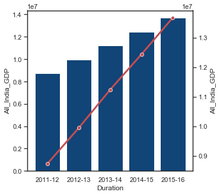

```python
# Sorting and resetting the index to ensure that the plots displayed are in order
dfCurrentPricesAllIndiaGDP = dfCurrentPricesAllIndiaGDP.sort_values(['All_India_GDP']).reset_index(inplace = True, drop = True)

# Assigning All India GDP values to the variable 'y' and (GDP Type and Duration) to variable 'x'
x = dfCurrentPrices.Duration
y = dfCurrentPrices.All_India_GDP

# Plotting both bar plot and best fit line in the same plot
sns.set(style="white", rc={"lines.linewidth": 3})

# Making bar plot and line lot on top of that
fig, ax1 = plt.subplots(figsize=(5,5))
ax2 = ax1.twinx()
sns.barplot(x, y, color='#004488', ax=ax1)
sns.lineplot(x, y, color='r', marker="o", ax=ax2)
plt.show()
sns.set()
```

#### GSDP - % Growth (All India GDP)

```python
# Subsetting all India % Growth in the variable dfPercentageGrowthAllIndiaGDP
dfPercentageGrowthAllIndiaGDP = dfPercentageGrowth.iloc[:, [1,-1]]

dfPercentageGrowthAllIndiaGDP.rename(columns={'All_India_GDP':'All_India_GDP_Percentage_Growth'}, inplace=True)
```

```python
dfPercentageGrowthAllIndiaGDP
```

|  | Duration | All_India_GDP_Percentage_Growth |
| --- | --- | --- |
| 0 | 2012-13 | 13.86 |
| 1 | 2013-14 | 12.97 |
| 2 | 2014-15 | 10.65 |
| 3 | 2015-16 | 9.99 |

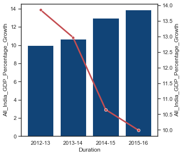

```python
# Sorting the GDP % Growth values to ensure optimal graphs for All India GDP
dfPercentageGrowthAllIndiaGDP = dfPercentageGrowthAllIndiaGDP.sort_values(['All_India_GDP_Percentage_Growth']).reset_index(drop = True)

# Assigning All India GDP values to the variable 'y' and (GDP Type and Duration) to variable 'x'
x = dfPercentageGrowthAllIndiaGDP.Duration
y = dfPercentageGrowthAllIndiaGDP.All_India_GDP_Percentage_Growth

# Plotting both bar plot and best fit line in the same plot
sns.set(style="white", rc={"lines.linewidth": 3})

fig, ax1 = plt.subplots(figsize=(5,5))
ax2 = ax1.twinx()

# Bar plot
sns.barplot(x, y, color='#004488', ax=ax1)

#Line Plot
sns.lineplot(x, y, color='r', marker="o", ax=ax2)
plt.show()
sns.set()
```

### State-Data without All India GDP (last column) will be analyzed now

```python
# Sense check of sliced % growth data
dfPercentageGrowth
```

|  | GDPType_Duration | Duration | Andhra Pradesh | Arunachal Pradesh | Assam | Bihar | Chhattisgarh | Goa | Gujarat | Haryana | Himachal Pradesh | Jammu & Kashmir | Jharkhand | Karnataka | Kerala | Madhya Pradesh | Maharashtra | Manipur | Meghalaya | Mizoram | Nagaland | Odisha | Punjab | Rajasthan | Sikkim | Tamil Nadu | Telangana | Tripura | Uttar Pradesh | … |
| --- | --- | --- | --- | --- | --- | --- | --- | --- | --- | --- | --- | --- | --- | --- | --- | --- | --- | --- | --- | --- | --- | --- | --- | --- | --- | --- | --- | --- | --- | --- |
| 0 | (% Growth over previous year) | 2012-13 | 8.43 | 13.41 | 9.56 | 14.25 | 12.30 | -10.02 | 17.69 | 16.63 | 13.89 | 11.31 | 15.77 | 14.56 | 13.26 | 20.71 | 13.79 | 6.45 | 9.81 | 15.2 | 15.03 | 13.34 | 11.67 | 13.18 | 10.51 | 13.84 | 11.70 | 12.78 | 13.65 | … |
| 1 | (% Growth over previous year) | 2013-14 | 12.85 | 16.38 | 13.31 | 12.30 | 16.44 | -5.77 | 11.47 | 15.45 | 14.42 | 10.09 | 7.92 | 18.24 | 12.79 | 14.91 | 13.74 | 17.83 | 4.87 | 23.1 | 21.98 | 12.95 | 12.42 | 11.27 | 12.35 | 13.51 | 12.63 | 18.14 | 14.73 | … |
| 2 | (% Growth over previous year) | 2014-15 | 13.40 | 14.79 | 11.45 | 17.92 | 13.69 | 13.12 | 10.82 | 9.18 | 10.14 | 4.70 | 15.14 | 12.70 | 13.11 | 10.11 | 8.78 | 11.39 | 6.41 | 12.3 | 10.85 | 10.37 | 9.95 | 11.37 | 9.72 | 12.51 | 13.05 | 15.92 | 10.51 | … |
| 3 | (% Growth over previous year) | 2015-16 | 15.85 | 12.07 | 13.19 | 10.59 | 10.98 | 10.75 | 11.09 | 10.91 | NaN | 17.91 | 11.44 | 11.42 | 11.85 | 12.86 | NaN | NaN | 9.58 | NaN | NaN | 6.19 | NaN | NaN | 9.39 | 10.99 | 12.61 | NaN | 10.58 | … |

```python
# Removing All_India_GDP from the dfCurrentProcess dataset to focus on the States
dfCurrentPrices = dfCurrentPrices.iloc[0:5, 1:29]
dfPercentageGrowth = dfPercentageGrowth.iloc[0:4, 1:29]
```

For the purposes of plotting, it is always preferred that one uses data in **tall-format**, rather than wide. So, we shall be transposing the sliced datasets of Current Prices and % growth.

```python
# Transposing the dfCurrentPrices dataset
tdfCurrentPrices = dfCurrentPrices.transpose()

# When transposing, the first column of the inital dataframe becomes the first row of the transposed dataframe
# Code to move the first rows of dataframe as column headers and drop first row
tdfCurrentPrices.columns = tdfCurrentPrices.iloc[0]
tdfCurrentPrices = tdfCurrentPrices.drop(tdfCurrentPrices.index[0])

# Typecasting the data from string (object) to type int
tdfCurrentPrices = tdfCurrentPrices.astype(str).astype(float)
tdfCurrentPrices['Average_Growth_Current_Price'] = tdfCurrentPrices.mean(axis = 1)

# Making the index a new column and re-indexing th pandas dataframe
tdfCurrentPrices['States'] = tdfCurrentPrices.index
tdfCurrentPrices.reset_index(inplace = True, drop = True)

# Printing the dataset for sense check
tdfCurrentPrices.head()
```

| Duration | 2011-12 | 2012-13 | 2013-14 | 2014-15 | 2015-16 | Average_Growth_Current_Price | States |
| --- | --- | --- | --- | --- | --- | --- | --- |
| 0 | 379402.0 | 411404.0 | 464272.0 | 526468.0 | 609934.0 | 478296.0 | Andhra Pradesh |
| 1 | 11063.0 | 12547.0 | 14602.0 | 16761.0 | 18784.0 | 14751.4 | Arunachal Pradesh |
| 2 | 143175.0 | 156864.0 | 177745.0 | 198098.0 | 224234.0 | 180023.2 | Assam |
| 3 | 247144.0 | 282368.0 | 317101.0 | 373920.0 | 413503.0 | 326807.2 | Bihar |
| 4 | 158074.0 | 177511.0 | 206690.0 | 234982.0 | 260776.0 | 207606.6 | Chhattisgarh |

## State-wise absolute Current Prices (2015-16)

```python
tdfCurrentPrices.head()
```

| Duration | 2011-12 | 2012-13 | 2013-14 | 2014-15 | 2015-16 | Average_Growth_Current_Price | States |
| --- | --- | --- | --- | --- | --- | --- | --- |
| 0 | 379402.0 | 411404.0 | 464272.0 | 526468.0 | 609934.0 | 478296.0 | Andhra Pradesh |
| 1 | 11063.0 | 12547.0 | 14602.0 | 16761.0 | 18784.0 | 14751.4 | Arunachal Pradesh |
| 2 | 143175.0 | 156864.0 | 177745.0 | 198098.0 | 224234.0 | 180023.2 | Assam |
| 3 | 247144.0 | 282368.0 | 317101.0 | 373920.0 | 413503.0 | 326807.2 | Bihar |
| 4 | 158074.0 | 177511.0 | 206690.0 | 234982.0 | 260776.0 | 207606.6 | Chhattisgarh |

# 2015-16 Current Prices

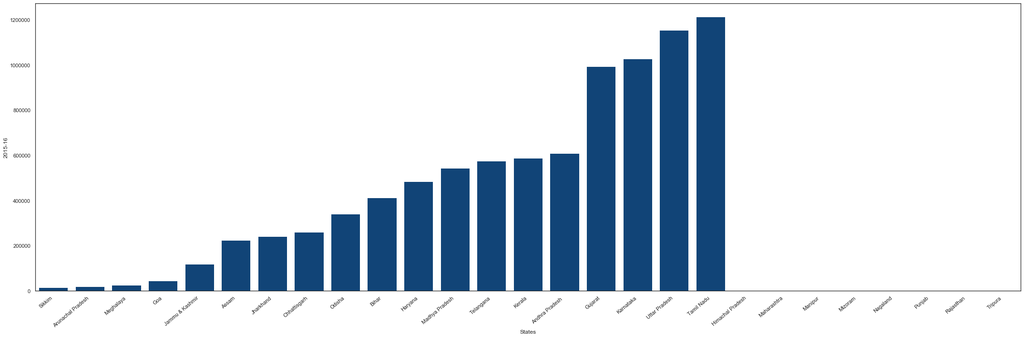

```python
# Sorting absolute Current Prices values
tdfCurrentPrices = tdfCurrentPrices.sort_values(['2015-16']).reset_index(drop = True)

# Specifying the values of x-axis and y-axis
x = tdfCurrentPrices.States
y = tdfCurrentPrices['2015-16']
sns.set(style="white")

# Deciding the size of the graph to be plotted
fig, ax = plt.subplots(figsize=(30,10))

# Plotting a bar plot
ax1 = sns.barplot(x, y, color='#004488')

# Rotating the State names by 45 degrees
ax1.set_xticklabels(ax.get_xticklabels(), rotation=40, ha="right")
plt.tight_layout()

# Displaying the plot along with the state names
plt.show()
sns.set()
```

# Current Growth Prices - Total GDP

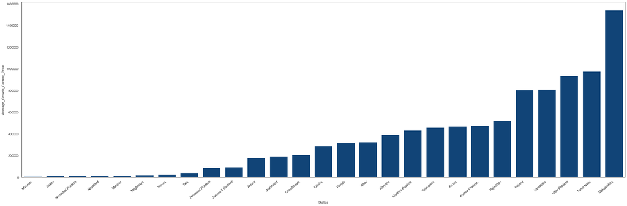

```python
# Sorting absolute Current Prices values
tdfCurrentPrices = tdfCurrentPrices.sort_values(['Average_Growth_Current_Price']).reset_index(drop = True)

# Specifying the values of x-axis and y-axis
x = tdfCurrentPrices.States
y = tdfCurrentPrices['Average_Growth_Current_Price']
sns.set(style="white")

# Deciding the size of the graph to be plotted
fig, ax = plt.subplots(figsize=(30,10))

# Plotting a bar plot
ax1 = sns.barplot(x, y, color='#004488')

# Rotating the State names by 45 degrees
ax1.set_xticklabels(ax.get_xticklabels(), rotation=40, ha="right")
plt.tight_layout()

# Displaying the plot along with the state names
plt.show()
sns.set()
```

## % Growth over previous years for all States:

```python
# Making a duplicate of the Percentage growth (state-wise)
df = dfPercentageGrowth

# Standardizing the dataset, removing extra spaces, replacing special characters etc.
df.columns = df.columns.str.strip().str.lower().str.replace(' ', '_').str.replace('(', '').str.replace(')', '')
df
```

|  | duration | andhra_pradesh | arunachal_pradesh | assam | bihar | chhattisgarh | goa | gujarat | haryana | himachal_pradesh | jammu_&_kashmir | jharkhand | karnataka | kerala | madhya_pradesh | maharashtra | manipur | meghalaya | mizoram | nagaland | odisha | punjab | rajasthan | sikkim | tamil_nadu | telangana | tripura | uttar_pradesh |
| --- | --- | --- | --- | --- | --- | --- | --- | --- | --- | --- | --- | --- | --- | --- | --- | --- | --- | --- | --- | --- | --- | --- | --- | --- | --- | --- | --- | --- |
| 0 | 2012-13 | 8.43 | 13.41 | 9.56 | 14.25 | 12.30 | -10.02 | 17.69 | 16.63 | 13.89 | 11.31 | 15.77 | 14.56 | 13.26 | 20.71 | 13.79 | 6.45 | 9.81 | 15.2 | 15.03 | 13.34 | 11.67 | 13.18 | 10.51 | 13.84 | 11.70 | 12.78 | 13.65 |
| 1 | 2013-14 | 12.85 | 16.38 | 13.31 | 12.30 | 16.44 | -5.77 | 11.47 | 15.45 | 14.42 | 10.09 | 7.92 | 18.24 | 12.79 | 14.91 | 13.74 | 17.83 | 4.87 | 23.1 | 21.98 | 12.95 | 12.42 | 11.27 | 12.35 | 13.51 | 12.63 | 18.14 | 14.73 |
| 2 | 2014-15 | 13.40 | 14.79 | 11.45 | 17.92 | 13.69 | 13.12 | 10.82 | 9.18 | 10.14 | 4.70 | 15.14 | 12.70 | 13.11 | 10.11 | 8.78 | 11.39 | 6.41 | 12.3 | 10.85 | 10.37 | 9.95 | 11.37 | 9.72 | 12.51 | 13.05 | 15.92 | 10.51 |
| 3 | 2015-16 | 15.85 | 12.07 | 13.19 | 10.59 | 10.98 | 10.75 | 11.09 | 10.91 | NaN | 17.91 | 11.44 | 11.42 | 11.85 | 12.86 | NaN | NaN | 9.58 | NaN | NaN | 6.19 | NaN | NaN | 9.39 | 10.99 | 12.61 | NaN | 10.58 |

```python
# Observing the data types of the dataframe
df.dtypes
```

```
duration              object
andhra_pradesh       float64
arunachal_pradesh    float64
assam                float64
bihar                float64
chhattisgarh         float64
goa                  float64
gujarat              float64
haryana              float64
himachal_pradesh     float64
jammu_&_kashmir      float64
jharkhand            float64
karnataka            float64
kerala               float64
madhya_pradesh       float64
maharashtra          float64
manipur              float64
meghalaya            float64
mizoram              float64
nagaland             float64
odisha               float64
punjab               float64
rajasthan            float64
sikkim               float64
tamil_nadu           float64
telangana            float64
tripura              float64
uttar_pradesh        float64
dtype: object
```

## Best fit line - States (Plots)

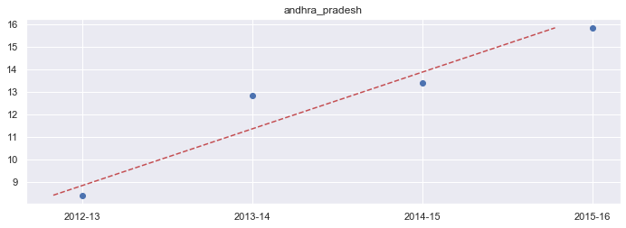

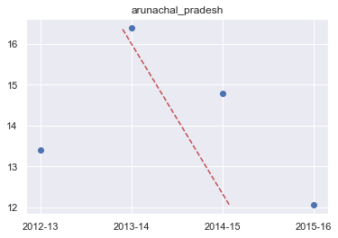

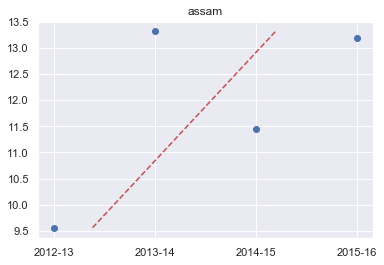

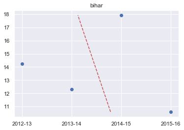

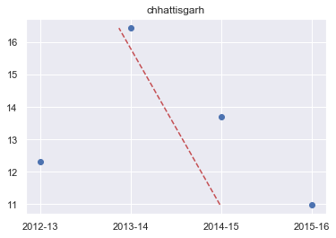

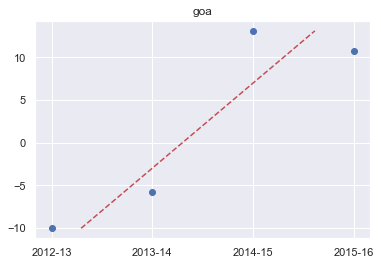

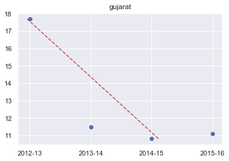

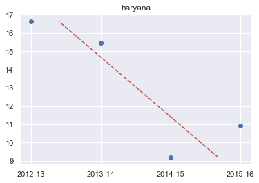

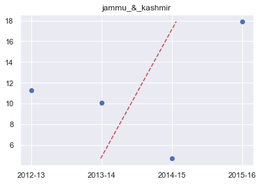

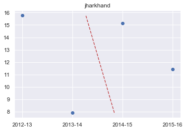

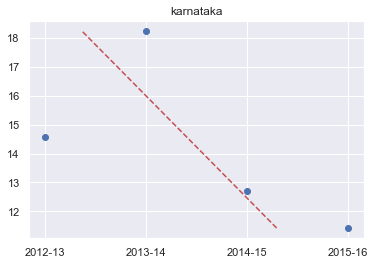

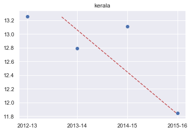

[7 more figures not shown]

```python
# Defining a user-defined function to take in the dataframe and the name of the state
# The purpose of the function is to plot a scatter plot as well as a best-fit line for the states

def scatterAndBestFitLine(df, stateName):
    y = df[stateName]
    plt.scatter(x = 'duration', y = stateName, data = df)
    plt.plot(np.poly1d(np.polyfit(y, np.arange(4), 1))(np.unique(y)),np.unique(y),  '--r')
    plt.gca().set_title(stateName)
    plt.show()

# Defining the canvas size and of the plots
fig = plt.figure(figsize=(40, 40))
fig.add_subplot(9, 3, 1)

# list of States for which scatter plot as well as best fit line is to be made
listOfStates = ['andhra_pradesh', 'arunachal_pradesh', 'assam', 'bihar', 'chhattisgarh', 'goa', 'gujarat', 'haryana',
                'jammu_&_kashmir', 'jharkhand', 'karnataka', 'kerala', 'madhya_pradesh', 'meghalaya', 'odisha', 'sikkim',
                'tamil_nadu', 'telangana',  'uttar_pradesh']

# Initializing a for loop to iterate through the states that have all 4 values populated
for i in listOfStates:
    scatterAndBestFitLine(df, i)
```

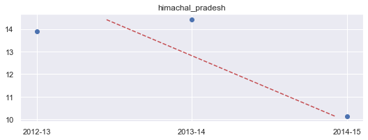

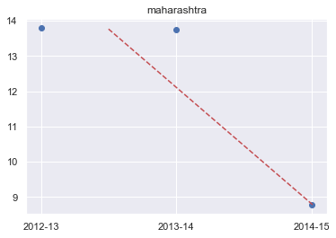

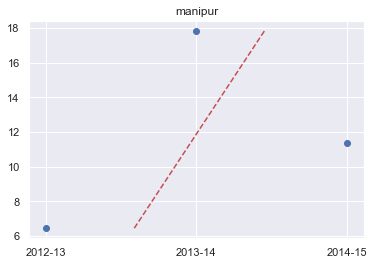

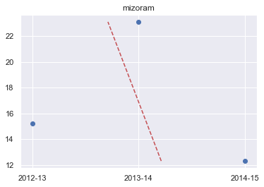

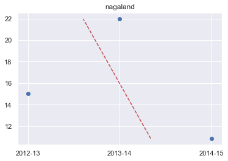

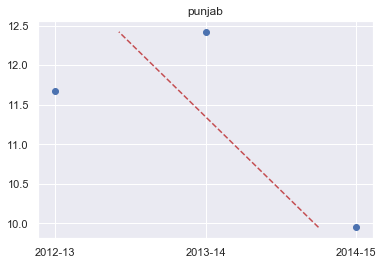

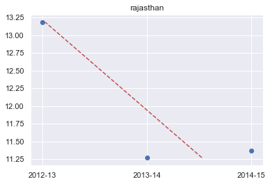

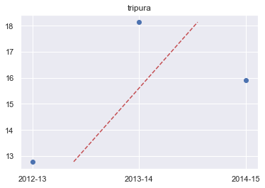

```python
# Defining a function to plot scatter plot and best-fit line for States that have 3 values populated
def scatterAndBestFitLine2(df, stateName):
    y = df[stateName]
    plt.scatter(x = 'duration', y = stateName, data = df)
    plt.plot(np.poly1d(np.polyfit(y, np.arange(3), 1))(np.unique(y)),np.unique(y),  '--r')
    plt.gca().set_title(stateName)
    plt.show()

# Defining the canvas and the figure size of the plots to be plotted
fig = plt.figure(figsize=(30, 30))

# Removing the rows that have the NaN values
df1 = df.iloc[0:-1,:]
fig.add_subplot(9, 3, 1)

# List of states that have 3 values populated in their respective columns
listOfStates2 = ['himachal_pradesh', 'maharashtra', 'manipur', 'mizoram', 'nagaland', 'punjab', 'rajasthan', 'tripura']

# Initializing a for loop to iterate through listOfStates2
for i in listOfStates2:
    scatterAndBestFitLine2(df1, i)
```

```python
# Transposing the dataset
tdfPercentageGrowth = dfPercentageGrowth.transpose()

# When transposing, the first column of the inital dataframe becomes the first row of the transposed dataframe
# Code to move the first rows of dataframe as column headers and drop first row
tdfPercentageGrowth.columns = tdfPercentageGrowth.iloc[0]
tdfPercentageGrowth = tdfPercentageGrowth.drop(tdfPercentageGrowth.index[0])

# Typecasting the data from string (object) to type int
tdfPercentageGrowth = tdfPercentageGrowth.astype(str).astype(float)
tdfPercentageGrowth['Average_Percentage_Growth'] = tdfPercentageGrowth.mean(axis = 1)

# Making the index a new column and re-indexing the pandas dataframe
tdfPercentageGrowth['States'] = tdfPercentageGrowth.index
tdfPercentageGrowth.reset_index(inplace = True, drop = True)

# Printing the dataset for sense check
tdfPercentageGrowth.head()
```

| duration | 2012-13 | 2013-14 | 2014-15 | 2015-16 | Average_Percentage_Growth | States |
| --- | --- | --- | --- | --- | --- | --- |
| 0 | 8.43 | 12.85 | 13.40 | 15.85 | 12.6325 | andhra_pradesh |
| 1 | 13.41 | 16.38 | 14.79 | 12.07 | 14.1625 | arunachal_pradesh |
| 2 | 9.56 | 13.31 | 11.45 | 13.19 | 11.8775 | assam |
| 3 | 14.25 | 12.30 | 17.92 | 10.59 | 13.7650 | bihar |
| 4 | 12.30 | 16.44 | 13.69 | 10.98 | 13.3525 | chhattisgarh |

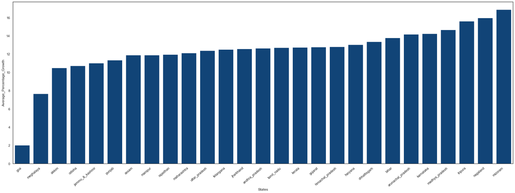

```python
# Sorting absolute Percentage growth values
tdfPercentageGrowth = tdfPercentageGrowth.sort_values(['Average_Percentage_Growth']).reset_index(drop = True)

# Specifying the values of x-axis and y-axis
x = tdfPercentageGrowth.States
y = tdfPercentageGrowth.Average_Percentage_Growth
sns.set(style="white")

# Deciding the size of the graph to be plotted
fig, ax = plt.subplots(figsize=(30,10))

# Rotating the State names by 45 degrees to make it easier to view
ax1 = sns.barplot(x, y, color='#004488')
ax1.set_xticklabels(ax.get_xticklabels(), rotation=40, ha="right")

# Displaying the plot along with the state names
plt.show()
sns.set()
```

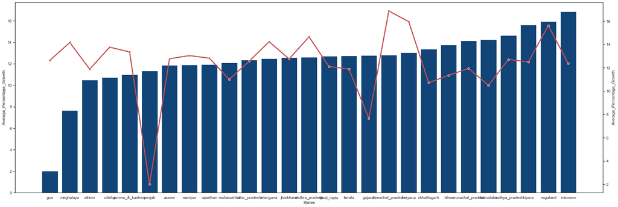

```python
# Sorting absolute Current Prices values
tdfPercentageGrowth = tdfPercentageGrowth.sort_values(['Average_Percentage_Growth']).reset_index(drop = True)

x = tdfPercentageGrowth.States
y = tdfPercentageGrowth.Average_Percentage_Growth
sns.set(style="white", rc={"lines.linewidth": 3})

fig, ax1 = plt.subplots(figsize=(30,10))
ax2 = ax1.twinx()

# Bar plot
sns.barplot(x, y, color='#004488', ax=ax1)
ax1 = sns.lineplot(x, y, color='r', marker="o")
ax1.set_xticklabels(ax.get_xticklabels(), rotation=40, ha="right")
# plt.tight_layout()

plt.show()
sns.set()
```

## Insights for Part 1-A

Post the cleaning of data and analysis of the same, we shall now proceed to answer the following questions:

Now that we have answered the above questions, we shall now proceed to perform the following analysis:

#### Plot the total GDP of the states for the year 2015-16:

1. Which Plot will you use for this? Why? (Remeber to plot the graph in a way such as it is easier to read and compare)
   - We can find the top GDP of states using the **bar plots** plotted under the section [State-wise absolute Current Prices (GDP Analysis)].
1. Identify the top 5 and the bottom 5 states based on total GDP.
   - The top 5 states are:
     - Tamil nadu
     - Uttar Pradesh
     - Karnataka
     - Gujrat
     - Andhra Pradesh
   - The bottom 5 states (from bottom to top) are:
     - Sikkim
     - Arunachal Pradesh
     - Meghalaya
     - Goa
     - Jammu & Kashmir
1. What insights can you draw from this graph? What states are performing poorly? (Remember: this will not be solely based on total GDP)
   - Even through Nagaland has less absolute GDP, the growth rate (% Growth) of Nagaland is among the top 3 in India for the defined time-period
   - The North-Eastern states of Mizoram, Nagaland and Tripura are in their prime growth. More focus should be given to developing state instead of focusing on larger GDPs as this would empower the states and result in quick wins.
   - Goa, being a prime tourist-destination should be focused more on to achieve higher year-on-year growth!
   - Lessons should be taken from the North-Eastern states on how to continuosly improve on % Growth year on year
   - **Sikkim** has not been able to catch up to the growth of the nation and special laws sould be formed to help improve the state

## Part I - B, GDP per capita, Segmentation

### Part I-B

*Note: The analysis is to be done for the years of **2014-15***

The analysis is to be formed for Indian States (exclusing union territories)

Following are the steps to be followed: Plot the GDP per capita for all the states.

```
- The bottom 5 states by GDP per capita are:
    * Bihar
    * Uttar Pradesh
    * Manipur
    * Assam
    * Jharkhand
```

- Q. Find the ratio of the highest per capita GDP to the lowest per capita GDP.
  - The ratio for (per capita GDP of Goa) / (per capita GDP for Bihar) is **8**

Plot the percentage contribution of the primary, secondary and tertiary sectors as a percentage of the total GDP for all the states.

- Which plot will you use here? Why?

  ```
    * I would prefer using a Stacked-bar char here. All of the information including breakdown of Primary, secondary and teriary can be represented in a single graph, which will also account for the contribution to the total GDP of the state
  ```

- Why is (Primary + Secondary + Tertiary) not equal to total GDP?
  - Sum of Primary, Secondary and Tertiary is equal to TOTAL GSVA at basic prices. On top of that two critical factors play-in which, in turn affects the overall State GDP (GSDP) which are:

    ```
     - Taxes on Products
     - Subsidies on products
    ```

-**Can you draw any insight from this? Find correlation of percentile of the state (% of states with lower GDP) and %contribution of Primary sector to total GDP.

- Categorise the states into four groups based on the GDP per capita (C1, C2, C3, C4, where C1 would have the highest per capita GDP and C4, the lowest). The quantile values are (0.20,0.5, 0.85, 1), i.e., the states lying between the 85th and the 100th percentile are in C1; those between the 50th and the 85th percentiles are in C2, and so on.

For each category (C1, C2, C3, C4): Find the top 3/4/5 sub-sectors (such as agriculture, forestry and fishing, crops, manufacturing etc., not primary, secondary and tertiary) that contribute to approximately 80% of the GSDP of each category.

```
- Note-I: The nomenclature for this project is as follows: primary, secondary and tertiary are named 'sectors', while agriculture, manufacturing etc. are named 'sub-sectors'.

- Note-II: If the top 3 sub-sectors contribute to, say, 79% of the GDP of some category, you can report "These top 3 sub-sectors contribute to approximately 80% of the GDP". This is to simplify the analysis and make the results consumable. (Remember, the CEO has to present the report to the CMs, and CMs have limited time; so, the analysis needs to be sharp
and concise.)
```

Plot the contribution of the sub-sectors as a percentage of the GSDP of each category.

```python
# Sense check of data  with filtered out Union Territories for the time period of 2014-2015
df = dfStateGDP
dfStateGDP
```

|  | State | Agriculture, forestry and fishing | Crops | Livestock | Forestry and logging | Fishing and aquaculture | Mining and quarrying | Primary | Manufacturing | Electricity, gas, water supply & other utility services | Construction | Secondary | Trade, repair, hotels and restaurants | Trade & repair services | Hotels & restaurants | Transport, storage, communication & services related to broadcasting | Railways | Road transport | Water transport | Air transport | Services incidental to transport | Storage | Communication & services related to broadcasting | Financial services | Real estate, ownership of dwelling & professional services | Public administration | Other services | Tertiary | TOTAL GSVA at basic prices | … |
| --- | --- | --- | --- | --- | --- | --- | --- | --- | --- | --- | --- | --- | --- | --- | --- | --- | --- | --- | --- | --- | --- | --- | --- | --- | --- | --- | --- | --- | --- | --- |
| 0 | AndhraPradesh | 14819416 | 7893514 | 4309078 | 346160 | 2270664 | 1484300 | 16303716 | 4672266 | 1151729 | 4664889 | 10488884 | 4233400 | 3716000 | 517400 | 5076984 | 424228 | 2816000 | 94200 | 14900 | 780200 | 18700 | 928756 | 1900863 | 4405409 | 2200897 | 4215389 | 22032942 | 48825542 | … |
| 1 | ArunachalPradesh | 686117 | 415520 | 38387 | 224017 | 8193 | 30842 | 716959 | 26120 | 113527 | 147842 | 287489 | 60421 | 56796 | 3625 | 35203 | 59 | 15467 | 0 | 0 | 109 | 0 | 19568 | 25207 | 48418 | 243867 | 218728 | 631844 | 1636292 | … |
| 2 | Assam | 3855548 | 2890544 | 173478 | 261987 | 529539 | 1471149 | 5326697 | 2002936 | 296587 | 1733568 | 4033091 | 2987155 | 2876251 | 110904 | 1194568 | 252509 | 507668 | 4502 | 26223 | 35739 | 10308 | 357619 | 543651 | 1412466 | 1373611 | 1795658 | 9307109 | 18666897 | … |
| 3 | Bihar | 7951890 | 4688237 | 2060296 | 550132 | 653224 | 68107 | 8019997 | 2189965 | 345168 | 3449763 | 5984896 | 7448373 | 7081391 | 366982 | 3147173 | 462413 | 1572288 | 2228 | 13599 | 166600 | 10618 | 919427 | 1178022 | 3740641 | 2078171 | 4587589 | 22179969 | 36184863 | … |
| 4 | Chattisgarh | 3948847 | 2613371 | 352208 | 597785 | 385483 | 2451970 | 6400817 | 4370593 | 1198438 | 2669855 | 8238886 | 1535571 | 1414164 | 121407 | 871770 | 159176 | 386628 | 0 | 9507 | 5232 | 16675 | 294552 | 739057 | 2462166 | 867982 | 1112232 | 7588778 | 22228481 | … |
| 5 | Goa | 308507 | 140421 | 30141 | 15744 | 122201 | 3622 | 312129 | 1177608 | 204110 | 165819 | 1547536 | 380927 | 343492 | 37434 | 189656 | 15649 | 46171 | 17820 | 46359 | 19272 | 357 | 44028 | 233618 | 407099 | 346486 | 180431 | 1738217 | 3597882 | … |
| 6 | Gujrat | 1.377e+07 | 9671086.0 | 2.69891e+06 | 761616 | 638357 | 2.11722e+06 | 1.58872e+07 | 2.40875e+07 | 3.40998e+06 | 5.52602e+06 | 3.30235e+07 | 1.01787e+07 | 1.01787e+07 | NaN | 4.55591e+06 | 511593 | NaN | NaN | NaN | 2.74416e+06 | 57634 | 1.24252e+06 | 4.60664e+06 | 5.1795e+06 | 2.5762e+06 | 3.12341e+06 | 3.02204e+07 | 7.91311e+07 | … |
| 7 | Harayana | 8.01524e+06 | 4636731.0 | 2.91617e+06 | 352254 | 110080 | 25186 | 8.04042e+06 | 7.75692e+06 | 1.10192e+06 | 3.70257e+06 | 1.25614e+07 | 4.98632e+06 | 4.81778e+06 | 168535 | 2.56062e+06 | 423873 | 1.45236e+06 | NaN | NaN | 190269 | 14459 | 479658 | 1.67149e+06 | 6.97018e+06 | 1.03638e+06 | 2.00158e+06 | 1.92266e+07 | 3.98284e+07 | … |
| 8 | HimachalPradesh | 1514981 | 853758 | 110304 | 540950 | 9968 | 33385 | 1548366 | 2543637 | 767268 | 808256 | 4119162 | 615496 | 494162 | 121333 | 552234 | 2528 | 349608 | 0 | 3979 | 1724 | 129 | 194266 | 362521 | 1125937 | 553974 | 923164 | 4133326 | 9800853 | … |
| 9 | Jharkhand | 3211065 | 2094466 | 562503 | 445149 | 108947 | 2037289 | 5248354 | 4114148 | 337489 | 1789834 | 6241471 | 1991359 | 1840196 | 151163 | 1470022 | 472702 | 649648 | 0 | 6716 | 17436 | 306 | 323214 | 551441 | 1656784 | 1088325 | 1375410 | 8133341 | 19623166 | … |
| 10 | Karnataka | 11219422 | 8157179 | 1868771 | 693082 | 500390 | 846882 | 12066304 | 12953843 | 1425762 | 6104799 | 20484404 | 8991658 | 7523720 | 1467938 | 5097652 | 259482 | 3194576 | 24152 | 171785 | 55349 | 42787 | 1349520 | 4094169 | 24766393 | 2232584 | 5308174 | 50490630 | 83041338 | … |
| 11 | Kerela | 5930617 | 3070386 | 1656104 | 499808 | 704319 | 558824 | 6489442 | 4273567 | 482470 | 7314003 | 12070040 | 8557345 | 7763847 | 793498 | 4020934 | 147897 | 2761427 | 26956 | 125029 | 71567 | 3290 | 884767 | 2010306 | 7287633 | 2068915 | 5728645 | 29673778 | 48233259 | … |
| 12 | MadhyaPradesh | 16235647 | 13216013 | 1932769 | 965588 | 121277 | 1618373 | 17854020 | 4368833 | 1272905 | 4403151 | 10044889 | 5357515 | 5053625 | 303890 | 2865802 | 498734 | 1369235 | 0 | 26746 | 36694 | 29012 | 905381 | 1988794 | 2660123 | 2497321 | 2747805 | 18117360 | 46016269 | … |
| 13 | Maharashtra | 16475655 | 10435121 | 3972829 | 1592564 | 475141 | 5282727 | 21758383 | 33660294 | 4334702 | 9450211 | 47445207 | 15839100 | 14286902 | 1552198 | 9697246 | 797933 | 4644123 | 223626 | 174188 | 1175023 | 131237 | 2551115 | 16143324 | 30718051 | 5426991 | 10806363 | 88631076 | 157834665 | … |
| 14 | Manipur | 383140 | 226583.0 | 75483 | 45831 | 35243 | NaN | 383140 | 49501 | 27490 | 143182 | 220173 | 262950 | 253637 | 9313 | 109726 | 6 | 58974 | NaN | 6288 | 2441 | NaN | 42017 | 30315 | 159335 | 297078 | 317930 | 1.17733e+06 | 1.78065e+06 | … |
| 15 | Meghalaya | 366521 | 223330.0 | 72442 | 61166 | 9583 | 84529 | 451050 | 433213 | 54473 | 150256 | 637942 | 383974 | 357727 | 26247 | 148189 | 0 | 105783 | NaN | 1443 | NaN | 416 | 40547 | 64091 | 150409 | 239782 | 214211 | 1.20066e+06 | 2.28965e+06 | … |
| 16 | Mizoram | 217010 | 116609 | 45590 | 47763 | 7048 | 8588 | 225598 | 8479 | 128365 | 133228 | 270072 | 114315 | 111324 | 2991 | 52587 | 32 | 34684 | 331 | 144 | 0 | 0 | 17395 | 23168 | 55068 | 206259 | 186222 | 637619 | 1133289 | … |
| 17 | Nagaland | 607897 | 375825 | 123800 | 99802 | 8470 | 8280 | 616178 | 18346 | 37944 | 156072 | 212361 | 140781 | 134174 | 6607 | 77521 | 336 | 34548 | 600 | 4153 | 0 | 89 | 37794 | 60393 | 159651 | 295424 | 259186 | 992956 | 1821495 | … |
| 18 | Odisha | 6422978 | 4382636 | 788243 | 791463 | 460636 | 2586328 | 9009306 | 5754229 | 833067 | 2402396 | 8989693 | 3149555 | 2886789 | 262766 | 2034016 | 341494 | 973144 | 50349 | 15354 | 117469 | 22675 | 513531 | 1065147 | 2348714 | 1318221 | 2340603 | 12256258 | 30255256 | … |
| 19 | Punjab | 9285716 | 5690972 | 2638842 | 848245 | 107657 | 10354 | 9296070 | 4790341 | 911611 | 2202962 | 7904914 | 4419919 | 4201252 | 218667 | 1951809 | 233389 | 928575 | 0 | 4473 | 48124 | 76429 | 660819 | 2057520 | 3142786 | 1842730 | 3303041 | 16717805 | 33918789 | … |
| 20 | Rajasthan | 15044394 | 7673441 | 5356257 | 1956660 | 58036 | 4069385 | 19113780 | 6552580 | 1122888 | 5353326 | 13028794 | 7297290 | 6942748 | 354543 | 3814461 | 464638 | 2121206 | 0 | 13469 | 47609 | 16584 | 1150955 | 1827413 | 6451997 | 2460364 | 4164287 | 26015812 | 58158386 | … |
| 21 | Sikkim | 137447 | 114976 | 17338 | 4529 | 604 | 1329 | 138776 | 550697 | 212499 | 82058 | 845253 | 70568 | 64624 | 5945 | 47347 | 0 | 35283 | 0 | 0 | 0 | 0 | 12064 | 21079 | 75330 | 119514 | 149265 | 483103 | 1467133 | … |
| 22 | TamilNadu | 13064238 | 7297820 | 4693361 | 392705 | 680352 | 265536 | 13329774 | 18914794 | 1710379 | 12216718 | 32841892 | 12895842 | 11252588 | 1643253 | 7188320 | 468553 | 3660994 | 70414 | 180836 | 864407 | 39834 | 1903283 | 5598498 | 16830213 | 3400800 | 7430115 | 53343788 | 99515453 | … |
| 23 | Telangana | 7591501 | 4162493 | 2951299 | 210741 | 266968 | 1541853 | 9133354 | 6353711 | 716266 | 2854024 | 9924001 | 6494607 | 5724128 | 770479 | 3604741 | 199686 | 2055658 | 0 | 120691 | 454909 | 19805 | 753992 | 3023729 | 9478839 | 1711265 | 4158229 | 28471410 | 47528765 | … |
| 24 | Tripura | 799825 | 397591.0 | 88176 | 145096 | 168961 | 142391 | 942216 | 228625 | 77870 | 177899 | 484393 | 390423 | 390423 | NaN | 155956 | 305 | NaN | NaN | NaN | 88721 | 254 | 66676 | 86094 | 190704 | 338244 | 323287 | 1.48471e+06 | 2.91132e+06 | … |
| 25 | Uttarakhand | 1.60142e+06 | 866146.0 | 391188 | 339293 | 4796 | 244549 | 1.84597e+06 | 5.86625e+06 | 433880 | 1.34273e+06 | 7.64286e+06 | 1.74311e+06 | 1.53407e+06 | 209033 | 1.06669e+06 | 21295 | 307147 | NaN | 3889 | -76 | 660 | 733778 | 385030 | 831307 | 579409 | 982430 | 5.58798e+06 | 1.50768e+07 | … |
| 26 | UttarPradesh | 25097754 | 16215212 | 7096876 | 1404936 | 380730 | 901501 | 25999255 | 12261649 | 2030625 | 11256450 | 25548724 | 9437243 | 8476139 | 961104 | 7404509 | 1618742 | 3645747 | 681 | 36582 | 16323 | 171696 | 1914737 | 3392275 | 14548185 | 6152124 | 5034623 | 45968959 | 97516938 | … |

## Plotting GDP per capita

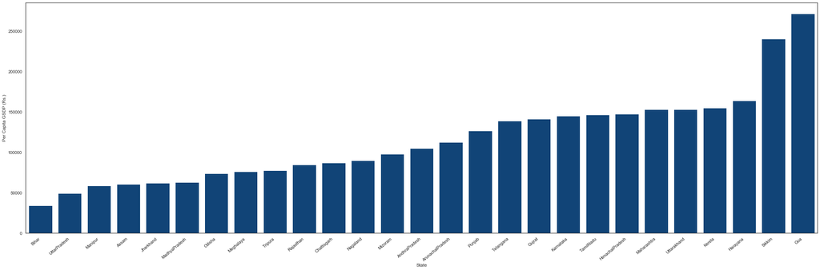

```python
# Sorting absolute Current Prices values
df = df.sort_values(['Per Capita GSDP (Rs.)']).reset_index(drop = True)

# Specifying the values of x-axis and y-axis
x = df.State
y = df['Per Capita GSDP (Rs.)']
sns.set(style="white")

# Deciding the size of the graph to be plotted
fig, ax = plt.subplots(figsize=(30,10))

# Plotting a bar plot
ax1 = sns.barplot(x, y, color='#004488')

# Rotating the State names by 45 degrees
ax1.set_xticklabels(ax.get_xticklabels(), rotation=40, ha="right")
plt.tight_layout()

# Displaying the plot along with the state names
plt.show()
sns.set()
```

```python
# Finding highest per capita GDP versus lowest per capita GDP
# Highest: Goa, Lowest: Bihar
df = dfStateGDP
perCapitaGDPGoa = df.iloc[5, 33]
perCapitaGDPBihar = df.iloc[3, 33]

# The question states to find the ratio
perCapitaGDPGoa/perCapitaGDPBihar
```

```
8.004741709371503
```

```python
df.shape
```

```
(27, 34)
```

```python
df = dfStateGDP
dfStateGDP.head()
```

|  | State | Agriculture, forestry and fishing | Crops | Livestock | Forestry and logging | Fishing and aquaculture | Mining and quarrying | Primary | Manufacturing | Electricity, gas, water supply & other utility services | Construction | Secondary | Trade, repair, hotels and restaurants | Trade & repair services | Hotels & restaurants | Transport, storage, communication & services related to broadcasting | Railways | Road transport | Water transport | Air transport | Services incidental to transport | Storage | Communication & services related to broadcasting | Financial services | Real estate, ownership of dwelling & professional services | Public administration | Other services | Tertiary | TOTAL GSVA at basic prices | … |
| --- | --- | --- | --- | --- | --- | --- | --- | --- | --- | --- | --- | --- | --- | --- | --- | --- | --- | --- | --- | --- | --- | --- | --- | --- | --- | --- | --- | --- | --- | --- |
| 0 | AndhraPradesh | 14819416 | 7893514 | 4309078 | 346160 | 2270664 | 1484300 | 16303716 | 4672266 | 1151729 | 4664889 | 10488884 | 4233400 | 3716000 | 517400 | 5076984 | 424228 | 2816000 | 94200 | 14900 | 780200 | 18700 | 928756 | 1900863 | 4405409 | 2200897 | 4215389 | 22032942 | 48825542 | … |
| 1 | ArunachalPradesh | 686117 | 415520 | 38387 | 224017 | 8193 | 30842 | 716959 | 26120 | 113527 | 147842 | 287489 | 60421 | 56796 | 3625 | 35203 | 59 | 15467 | 0 | 0 | 109 | 0 | 19568 | 25207 | 48418 | 243867 | 218728 | 631844 | 1636292 | … |
| 2 | Assam | 3855548 | 2890544 | 173478 | 261987 | 529539 | 1471149 | 5326697 | 2002936 | 296587 | 1733568 | 4033091 | 2987155 | 2876251 | 110904 | 1194568 | 252509 | 507668 | 4502 | 26223 | 35739 | 10308 | 357619 | 543651 | 1412466 | 1373611 | 1795658 | 9307109 | 18666897 | … |
| 3 | Bihar | 7951890 | 4688237 | 2060296 | 550132 | 653224 | 68107 | 8019997 | 2189965 | 345168 | 3449763 | 5984896 | 7448373 | 7081391 | 366982 | 3147173 | 462413 | 1572288 | 2228 | 13599 | 166600 | 10618 | 919427 | 1178022 | 3740641 | 2078171 | 4587589 | 22179969 | 36184863 | … |
| 4 | Chattisgarh | 3948847 | 2613371 | 352208 | 597785 | 385483 | 2451970 | 6400817 | 4370593 | 1198438 | 2669855 | 8238886 | 1535571 | 1414164 | 121407 | 871770 | 159176 | 386628 | 0 | 9507 | 5232 | 16675 | 294552 | 739057 | 2462166 | 867982 | 1112232 | 7588778 | 22228481 | … |

### Stacked bar chart to identify Primary, Secondary and Tertiary contribution to Gross State Domestic Product

```python
# Selecting the relevant columns to make stacked bar chart on the basis of % of State GDP
df = dfStateGDP[['State', 'Primary', 'Secondary', 'Tertiary', 'TOTAL GSVA at basic prices', 'Gross State Domestic Product']]

# Making new columns to represent the Primary, Secondary and Tertiary as a percentage of GDP
df['primaryPercentage'] = (df['Primary']/ df['Gross State Domestic Product'])* 100
df['secondaryPercentage'] = (df['Secondary']/ df['Gross State Domestic Product'])* 100
df['tertiaryPercetage'] = (df['Tertiary']/ df['Gross State Domestic Product'])* 100

# Dropping columns that will not be used for stacked bar chart
df = df.drop(['Primary', 'Secondary', 'Tertiary', 'TOTAL GSVA at basic prices'], axis = 1)

# Sorting absolute Percentage growth values
df = df.sort_values(['Gross State Domestic Product']).reset_index(drop = True)

# Setting the index as the State to get sorted stacked bar chart
df.set_index('State', inplace=True)

# Dropping irrevant column to graph
df = df.drop(['Gross State Domestic Product'], axis = 1)

df.head()
```

| State | primaryPercentage | secondaryPercentage | tertiaryPercetage |
| --- | --- | --- | --- |
| Mizoram | 19.5165 | 23.364 | 55.1605 |
| Sikkim | 9.1244 | 55.5746 | 31.7636 |
| ArunachalPradesh | 42.7749 | 17.1521 | 37.6968 |
| Manipur | 21.2351 | 12.2028 | 65.2524 |
| Nagaland | 33.462 | 11.5324 | 53.9233 |

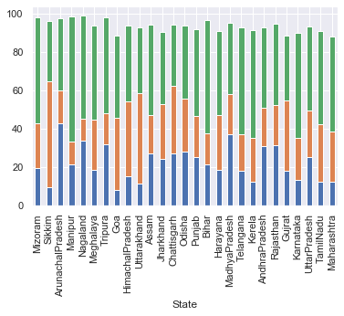

```python
# Plotting the bar chart
df.plot(kind='bar',stacked=True,legend=False)
plt.show()
```

## Categorizing the data into C1, C2, C3, C4

The method to this problem is given below:

- Perform Sense checks on the dataset
- Divide into C1, C2, C3, C4 on the basis of mentioned percentile values
- Take these separate dataframes (sliced) and add a new column to indicate the segment
- Convert the dataset into float
- Aggregate on the basis of segment
- Remove the "sectors" and keep the "sub-sectors" (per the nomenclature mention in the question)
- Sort the values with the sub-sectors as segment to find top contributing sub-sectors

```python
df = dfStateGDP
```

```python
df1 = df
df.head()
```

|  | State | Agriculture, forestry and fishing | Crops | Livestock | Forestry and logging | Fishing and aquaculture | Mining and quarrying | Primary | Manufacturing | Electricity, gas, water supply & other utility services | Construction | Secondary | Trade, repair, hotels and restaurants | Trade & repair services | Hotels & restaurants | Transport, storage, communication & services related to broadcasting | Railways | Road transport | Water transport | Air transport | Services incidental to transport | Storage | Communication & services related to broadcasting | Financial services | Real estate, ownership of dwelling & professional services | Public administration | Other services | Tertiary | TOTAL GSVA at basic prices | … |
| --- | --- | --- | --- | --- | --- | --- | --- | --- | --- | --- | --- | --- | --- | --- | --- | --- | --- | --- | --- | --- | --- | --- | --- | --- | --- | --- | --- | --- | --- | --- |
| 0 | AndhraPradesh | 14819416 | 7893514 | 4309078 | 346160 | 2270664 | 1484300 | 16303716 | 4672266 | 1151729 | 4664889 | 10488884 | 4233400 | 3716000 | 517400 | 5076984 | 424228 | 2816000 | 94200 | 14900 | 780200 | 18700 | 928756 | 1900863 | 4405409 | 2200897 | 4215389 | 22032942 | 48825542 | … |
| 1 | ArunachalPradesh | 686117 | 415520 | 38387 | 224017 | 8193 | 30842 | 716959 | 26120 | 113527 | 147842 | 287489 | 60421 | 56796 | 3625 | 35203 | 59 | 15467 | 0 | 0 | 109 | 0 | 19568 | 25207 | 48418 | 243867 | 218728 | 631844 | 1636292 | … |
| 2 | Assam | 3855548 | 2890544 | 173478 | 261987 | 529539 | 1471149 | 5326697 | 2002936 | 296587 | 1733568 | 4033091 | 2987155 | 2876251 | 110904 | 1194568 | 252509 | 507668 | 4502 | 26223 | 35739 | 10308 | 357619 | 543651 | 1412466 | 1373611 | 1795658 | 9307109 | 18666897 | … |
| 3 | Bihar | 7951890 | 4688237 | 2060296 | 550132 | 653224 | 68107 | 8019997 | 2189965 | 345168 | 3449763 | 5984896 | 7448373 | 7081391 | 366982 | 3147173 | 462413 | 1572288 | 2228 | 13599 | 166600 | 10618 | 919427 | 1178022 | 3740641 | 2078171 | 4587589 | 22179969 | 36184863 | … |
| 4 | Chattisgarh | 3948847 | 2613371 | 352208 | 597785 | 385483 | 2451970 | 6400817 | 4370593 | 1198438 | 2669855 | 8238886 | 1535571 | 1414164 | 121407 | 871770 | 159176 | 386628 | 0 | 9507 | 5232 | 16675 | 294552 | 739057 | 2462166 | 867982 | 1112232 | 7588778 | 22228481 | … |

```python
# Renaming the column
df.rename(columns={'Per Capita GSDP (Rs.)':'perCapitaGDP'}, inplace=True)
df.head()
```

|  | State | Agriculture, forestry and fishing | Crops | Livestock | Forestry and logging | Fishing and aquaculture | Mining and quarrying | Primary | Manufacturing | Electricity, gas, water supply & other utility services | Construction | Secondary | Trade, repair, hotels and restaurants | Trade & repair services | Hotels & restaurants | Transport, storage, communication & services related to broadcasting | Railways | Road transport | Water transport | Air transport | Services incidental to transport | Storage | Communication & services related to broadcasting | Financial services | Real estate, ownership of dwelling & professional services | Public administration | Other services | Tertiary | TOTAL GSVA at basic prices | … |
| --- | --- | --- | --- | --- | --- | --- | --- | --- | --- | --- | --- | --- | --- | --- | --- | --- | --- | --- | --- | --- | --- | --- | --- | --- | --- | --- | --- | --- | --- | --- |
| 0 | AndhraPradesh | 14819416 | 7893514 | 4309078 | 346160 | 2270664 | 1484300 | 16303716 | 4672266 | 1151729 | 4664889 | 10488884 | 4233400 | 3716000 | 517400 | 5076984 | 424228 | 2816000 | 94200 | 14900 | 780200 | 18700 | 928756 | 1900863 | 4405409 | 2200897 | 4215389 | 22032942 | 48825542 | … |
| 1 | ArunachalPradesh | 686117 | 415520 | 38387 | 224017 | 8193 | 30842 | 716959 | 26120 | 113527 | 147842 | 287489 | 60421 | 56796 | 3625 | 35203 | 59 | 15467 | 0 | 0 | 109 | 0 | 19568 | 25207 | 48418 | 243867 | 218728 | 631844 | 1636292 | … |
| 2 | Assam | 3855548 | 2890544 | 173478 | 261987 | 529539 | 1471149 | 5326697 | 2002936 | 296587 | 1733568 | 4033091 | 2987155 | 2876251 | 110904 | 1194568 | 252509 | 507668 | 4502 | 26223 | 35739 | 10308 | 357619 | 543651 | 1412466 | 1373611 | 1795658 | 9307109 | 18666897 | … |
| 3 | Bihar | 7951890 | 4688237 | 2060296 | 550132 | 653224 | 68107 | 8019997 | 2189965 | 345168 | 3449763 | 5984896 | 7448373 | 7081391 | 366982 | 3147173 | 462413 | 1572288 | 2228 | 13599 | 166600 | 10618 | 919427 | 1178022 | 3740641 | 2078171 | 4587589 | 22179969 | 36184863 | … |
| 4 | Chattisgarh | 3948847 | 2613371 | 352208 | 597785 | 385483 | 2451970 | 6400817 | 4370593 | 1198438 | 2669855 | 8238886 | 1535571 | 1414164 | 121407 | 871770 | 159176 | 386628 | 0 | 9507 | 5232 | 16675 | 294552 | 739057 | 2462166 | 867982 | 1112232 | 7588778 | 22228481 | … |

```python
# Quantile values: (0.20 - C1, 0.5 - C2, 0.85 - C3, 1 - C4)
# breaking the data into 4 values on the basis of the above rules

# Category C1 - 0 to 20 percentile
df20Percentile = df[df.perCapitaGDP <= df.perCapitaGDP.quantile(.2)]
df20Percentile.reset_index(inplace = True, drop = True)

# Category C2 - 20 to 50 percentile
df20to50Percentile = df[ (df.perCapitaGDP > df.perCapitaGDP.quantile(.2)) & (df.perCapitaGDP <= df.perCapitaGDP.quantile(.5))]
df20to50Percentile.reset_index(inplace = True, drop = True)

# Category C3 - 50 to 85 percentile
df50to85Percentile = df[ (df.perCapitaGDP > df.perCapitaGDP.quantile(0.5)) & (df.perCapitaGDP <= df.perCapitaGDP.quantile(.85))]
df50to85Percentile.reset_index(inplace = True, drop = True)

# Category C4 - 85 to 100 percentile
df85to100Percentile = df[ (df.perCapitaGDP > df.perCapitaGDP.quantile(0.85))]
df85to100Percentile.reset_index(inplace = True, drop = True)
```

```python
# Displaying the df20Percentile for sense check
df20Percentile.head()
```

|  | State | Agriculture, forestry and fishing | Crops | Livestock | Forestry and logging | Fishing and aquaculture | Mining and quarrying | Primary | Manufacturing | Electricity, gas, water supply & other utility services | Construction | Secondary | Trade, repair, hotels and restaurants | Trade & repair services | Hotels & restaurants | Transport, storage, communication & services related to broadcasting | Railways | Road transport | Water transport | Air transport | Services incidental to transport | Storage | Communication & services related to broadcasting | Financial services | Real estate, ownership of dwelling & professional services | Public administration | Other services | Tertiary | TOTAL GSVA at basic prices | … |
| --- | --- | --- | --- | --- | --- | --- | --- | --- | --- | --- | --- | --- | --- | --- | --- | --- | --- | --- | --- | --- | --- | --- | --- | --- | --- | --- | --- | --- | --- | --- |
| 0 | Assam | 3855548 | 2890544 | 173478 | 261987 | 529539 | 1471149 | 5326697 | 2002936 | 296587 | 1733568 | 4033091 | 2987155 | 2876251 | 110904 | 1194568 | 252509 | 507668 | 4502 | 26223 | 35739 | 10308 | 357619 | 543651 | 1412466 | 1373611 | 1795658 | 9307109 | 18666897 | … |
| 1 | Bihar | 7951890 | 4688237 | 2060296 | 550132 | 653224 | 68107 | 8019997 | 2189965 | 345168 | 3449763 | 5984896 | 7448373 | 7081391 | 366982 | 3147173 | 462413 | 1572288 | 2228 | 13599 | 166600 | 10618 | 919427 | 1178022 | 3740641 | 2078171 | 4587589 | 22179969 | 36184863 | … |
| 2 | Jharkhand | 3211065 | 2094466 | 562503 | 445149 | 108947 | 2037289 | 5248354 | 4114148 | 337489 | 1789834 | 6241471 | 1991359 | 1840196 | 151163 | 1470022 | 472702 | 649648 | 0 | 6716 | 17436 | 306 | 323214 | 551441 | 1656784 | 1088325 | 1375410 | 8133341 | 19623166 | … |
| 3 | MadhyaPradesh | 16235647 | 13216013 | 1932769 | 965588 | 121277 | 1618373 | 17854020 | 4368833 | 1272905 | 4403151 | 10044889 | 5357515 | 5053625 | 303890 | 2865802 | 498734 | 1369235 | 0 | 26746 | 36694 | 29012 | 905381 | 1988794 | 2660123 | 2497321 | 2747805 | 18117360 | 46016269 | … |
| 4 | Manipur | 383140 | 226583.0 | 75483 | 45831 | 35243 | NaN | 383140 | 49501 | 27490 | 143182 | 220173 | 262950 | 253637 | 9313 | 109726 | 6 | 58974 | NaN | 6288 | 2441 | NaN | 42017 | 30315 | 159335 | 297078 | 317930 | 1.17733e+06 | 1.78065e+06 | … |

```python
# Displaying the df20to50Percentile for sense check
df20to50Percentile.head()
```

|  | State | Agriculture, forestry and fishing | Crops | Livestock | Forestry and logging | Fishing and aquaculture | Mining and quarrying | Primary | Manufacturing | Electricity, gas, water supply & other utility services | Construction | Secondary | Trade, repair, hotels and restaurants | Trade & repair services | Hotels & restaurants | Transport, storage, communication & services related to broadcasting | Railways | Road transport | Water transport | Air transport | Services incidental to transport | Storage | Communication & services related to broadcasting | Financial services | Real estate, ownership of dwelling & professional services | Public administration | Other services | Tertiary | TOTAL GSVA at basic prices | … |
| --- | --- | --- | --- | --- | --- | --- | --- | --- | --- | --- | --- | --- | --- | --- | --- | --- | --- | --- | --- | --- | --- | --- | --- | --- | --- | --- | --- | --- | --- | --- |
| 0 | AndhraPradesh | 14819416 | 7893514 | 4309078 | 346160 | 2270664 | 1484300 | 16303716 | 4672266 | 1151729 | 4664889 | 10488884 | 4233400 | 3716000 | 517400 | 5076984 | 424228 | 2816000 | 94200 | 14900 | 780200 | 18700 | 928756 | 1900863 | 4405409 | 2200897 | 4215389 | 22032942 | 48825542 | … |
| 1 | Chattisgarh | 3948847 | 2613371 | 352208 | 597785 | 385483 | 2451970 | 6400817 | 4370593 | 1198438 | 2669855 | 8238886 | 1535571 | 1414164 | 121407 | 871770 | 159176 | 386628 | 0 | 9507 | 5232 | 16675 | 294552 | 739057 | 2462166 | 867982 | 1112232 | 7588778 | 22228481 | … |
| 2 | Meghalaya | 366521 | 223330.0 | 72442 | 61166 | 9583 | 84529 | 451050 | 433213 | 54473 | 150256 | 637942 | 383974 | 357727 | 26247 | 148189 | 0 | 105783 | NaN | 1443 | NaN | 416 | 40547 | 64091 | 150409 | 239782 | 214211 | 1.20066e+06 | 2.28965e+06 | … |
| 3 | Mizoram | 217010 | 116609 | 45590 | 47763 | 7048 | 8588 | 225598 | 8479 | 128365 | 133228 | 270072 | 114315 | 111324 | 2991 | 52587 | 32 | 34684 | 331 | 144 | 0 | 0 | 17395 | 23168 | 55068 | 206259 | 186222 | 637619 | 1133289 | … |
| 4 | Nagaland | 607897 | 375825 | 123800 | 99802 | 8470 | 8280 | 616178 | 18346 | 37944 | 156072 | 212361 | 140781 | 134174 | 6607 | 77521 | 336 | 34548 | 600 | 4153 | 0 | 89 | 37794 | 60393 | 159651 | 295424 | 259186 | 992956 | 1821495 | … |

```python
# Displaying the df50to85Percentile for sense check
df50to85Percentile.head()
```

|  | State | Agriculture, forestry and fishing | Crops | Livestock | Forestry and logging | Fishing and aquaculture | Mining and quarrying | Primary | Manufacturing | Electricity, gas, water supply & other utility services | Construction | Secondary | Trade, repair, hotels and restaurants | Trade & repair services | Hotels & restaurants | Transport, storage, communication & services related to broadcasting | Railways | Road transport | Water transport | Air transport | Services incidental to transport | Storage | Communication & services related to broadcasting | Financial services | Real estate, ownership of dwelling & professional services | Public administration | Other services | Tertiary | TOTAL GSVA at basic prices | … |
| --- | --- | --- | --- | --- | --- | --- | --- | --- | --- | --- | --- | --- | --- | --- | --- | --- | --- | --- | --- | --- | --- | --- | --- | --- | --- | --- | --- | --- | --- | --- |
| 0 | ArunachalPradesh | 686117 | 415520 | 38387 | 224017 | 8193 | 30842 | 716959 | 26120 | 113527 | 147842 | 287489 | 60421 | 56796 | 3625 | 35203 | 59 | 15467 | 0 | 0 | 109 | 0 | 19568 | 25207 | 48418 | 243867 | 218728 | 631844 | 1636292 | … |
| 1 | Gujrat | 1.377e+07 | 9671086.0 | 2.69891e+06 | 761616 | 638357 | 2.11722e+06 | 1.58872e+07 | 2.40875e+07 | 3.40998e+06 | 5.52602e+06 | 3.30235e+07 | 1.01787e+07 | 1.01787e+07 | NaN | 4.55591e+06 | 511593 | NaN | NaN | NaN | 2.74416e+06 | 57634 | 1.24252e+06 | 4.60664e+06 | 5.1795e+06 | 2.5762e+06 | 3.12341e+06 | 3.02204e+07 | 7.91311e+07 | … |
| 2 | HimachalPradesh | 1514981 | 853758 | 110304 | 540950 | 9968 | 33385 | 1548366 | 2543637 | 767268 | 808256 | 4119162 | 615496 | 494162 | 121333 | 552234 | 2528 | 349608 | 0 | 3979 | 1724 | 129 | 194266 | 362521 | 1125937 | 553974 | 923164 | 4133326 | 9800853 | … |
| 3 | Karnataka | 11219422 | 8157179 | 1868771 | 693082 | 500390 | 846882 | 12066304 | 12953843 | 1425762 | 6104799 | 20484404 | 8991658 | 7523720 | 1467938 | 5097652 | 259482 | 3194576 | 24152 | 171785 | 55349 | 42787 | 1349520 | 4094169 | 24766393 | 2232584 | 5308174 | 50490630 | 83041338 | … |
| 4 | Maharashtra | 16475655 | 10435121 | 3972829 | 1592564 | 475141 | 5282727 | 21758383 | 33660294 | 4334702 | 9450211 | 47445207 | 15839100 | 14286902 | 1552198 | 9697246 | 797933 | 4644123 | 223626 | 174188 | 1175023 | 131237 | 2551115 | 16143324 | 30718051 | 5426991 | 10806363 | 88631076 | 157834665 | … |

```python
# Displaying the df85to100Percentile for sense check
df85to100Percentile.head()
```

|  | State | Agriculture, forestry and fishing | Crops | Livestock | Forestry and logging | Fishing and aquaculture | Mining and quarrying | Primary | Manufacturing | Electricity, gas, water supply & other utility services | Construction | Secondary | Trade, repair, hotels and restaurants | Trade & repair services | Hotels & restaurants | Transport, storage, communication & services related to broadcasting | Railways | Road transport | Water transport | Air transport | Services incidental to transport | Storage | Communication & services related to broadcasting | Financial services | Real estate, ownership of dwelling & professional services | Public administration | Other services | Tertiary | TOTAL GSVA at basic prices | … |
| --- | --- | --- | --- | --- | --- | --- | --- | --- | --- | --- | --- | --- | --- | --- | --- | --- | --- | --- | --- | --- | --- | --- | --- | --- | --- | --- | --- | --- | --- | --- |
| 0 | Goa | 308507 | 140421 | 30141 | 15744 | 122201 | 3622 | 312129 | 1177608 | 204110 | 165819 | 1547536 | 380927 | 343492 | 37434 | 189656 | 15649 | 46171 | 17820 | 46359 | 19272 | 357 | 44028 | 233618 | 407099 | 346486 | 180431 | 1738217 | 3597882 | … |
| 1 | Harayana | 8.01524e+06 | 4636731.0 | 2.91617e+06 | 352254 | 110080 | 25186 | 8.04042e+06 | 7.75692e+06 | 1.10192e+06 | 3.70257e+06 | 1.25614e+07 | 4.98632e+06 | 4.81778e+06 | 168535 | 2.56062e+06 | 423873 | 1.45236e+06 | NaN | NaN | 190269 | 14459 | 479658 | 1.67149e+06 | 6.97018e+06 | 1.03638e+06 | 2.00158e+06 | 1.92266e+07 | 3.98284e+07 | … |
| 2 | Kerela | 5930617 | 3070386 | 1656104 | 499808 | 704319 | 558824 | 6489442 | 4273567 | 482470 | 7314003 | 12070040 | 8557345 | 7763847 | 793498 | 4020934 | 147897 | 2761427 | 26956 | 125029 | 71567 | 3290 | 884767 | 2010306 | 7287633 | 2068915 | 5728645 | 29673778 | 48233259 | … |
| 3 | Sikkim | 137447 | 114976 | 17338 | 4529 | 604 | 1329 | 138776 | 550697 | 212499 | 82058 | 845253 | 70568 | 64624 | 5945 | 47347 | 0 | 35283 | 0 | 0 | 0 | 0 | 12064 | 21079 | 75330 | 119514 | 149265 | 483103 | 1467133 | … |

```python
# Setting the index as the State to get sorted stacked bar chart

# Making a function to get the sum() aggregation of dataset

def makeAggregatedSum(df, segmentationType):

    # Making the state column the index
    df.set_index('State', inplace=True)

    # Converting the rest of the data types from string to float
    df = df.iloc[:, 1:34].astype(str).astype(float)

    # Assigning the segmentation type of C1, C2, C3 and C4 to the concerned dataframe
    df['Segmentation'] = segmentationType

    # Grouping by the segmentation type
    df = df.groupby(['Segmentation']).sum()
    return df

# For the purposes of this analysis, we shall be considering the sub-sectors,
# so, the primary, secondary and tertiary columns will be removed
redundant_columns = ['Primary', 'Secondary', 'Tertiary']
```

**!Important Note:**

#### The variables are mislabelled as the categorization made was inverted. Kindly focus on insights and markdown cells as they consist of correct interpretations

## 20 percentile - C4 to identify top sub-sectors

```python
# mdf20Percentile -> modified dfPercentile20
# Passing to the makeAggregatedSum function to aggregate by C1
mdf20Percentile = makeAggregatedSum(df20Percentile, 'C1')
mdf20Percentile = mdf20Percentile.drop(redundant_columns, 1)
mdf20Percentile.head()
```

| Segmentation | Crops | Livestock | Forestry and logging | Fishing and aquaculture | Mining and quarrying | Manufacturing | Electricity, gas, water supply & other utility services | Construction | Trade, repair, hotels and restaurants | Trade & repair services | Hotels & restaurants | Transport, storage, communication & services related to broadcasting | Railways | Road transport | Water transport | Air transport | Services incidental to transport | Storage | Communication & services related to broadcasting | Financial services | Real estate, ownership of dwelling & professional services | Public administration | Other services | TOTAL GSVA at basic prices | Taxes on Products | Subsidies on products | Gross State Domestic Product | Population ('00) | perCapitaGDP |
| --- | --- | --- | --- | --- | --- | --- | --- | --- | --- | --- | --- | --- | --- | --- | --- | --- | --- | --- | --- | --- | --- | --- | --- | --- | --- | --- | --- | --- | --- |
| C1 | 39331055.0 | 11901405.0 | 3673623.0 | 1828960.0 | 6096419.0 | 24987032.0 | 4310264.0 | 22775948.0 | 27484595.0 | 25581239.0 | 1903356.0 | 16191800.0 | 3305106.0 | 7803560.0 | 7411.0 | 116154.0 | 275233.0 | 221940.0 | 4462395.0 | 7684498.0 | 24177534.0 | 13486630.0 | 15859015.0 | 219788780.0 | 21922888.0 | 8459602.0 | 233252066.0 | 4683673.0 | 327547.0 |

```python
# Transposing the dataset
mdf20Percentile = mdf20Percentile.transpose()

# Getting the total GSVA in a variable
totGSVA20 = mdf20Percentile.loc['TOTAL GSVA at basic prices', 'C1']

# Making a new column to get the percentage contribution to TOTAL GSVA at basic prices
mdf20Percentile['percentageOfTotalGSVA'] = round (((mdf20Percentile['C1']/ totGSVA20)* 100),2)

# Sorting the percentage values in descending order to get the sub-sectors that account for 80%
mdf20Percentile = mdf20Percentile.sort_values(['C1'], ascending=[False])

mdf20Percentile.head(10)
```

| Segmentation 0 | C1 | percentageOfTotalGSVA |
| --- | --- | --- |
| Gross State Domestic Product | 233252066.0 | 106.13 |
| TOTAL GSVA at basic prices | 219788780.0 | 100.00 |
| Crops | 39331055.0 | 17.89 |
| Trade, repair, hotels and restaurants | 27484595.0 | 12.51 |
| Trade & repair services | 25581239.0 | 11.64 |
| Manufacturing | 24987032.0 | 11.37 |
| Real estate, ownership of dwelling & professional services | 24177534.0 | 11.00 |
| Construction | 22775948.0 | 10.36 |
| Taxes on Products | 21922888.0 | 9.97 |
| Transport, storage, communication & services related to broadcasting | 16191800.0 | 7.37 |

## C3 -> 20 to 50 percentile

```python
# mdf20to50Percentile -> modified df20to50Percentile
# Passing to the makeAggregatedSum() function to aggregate by C2
mdf20to50Percentile = makeAggregatedSum(df20to50Percentile, 'C2')

# Displaying the df20to50Percentile for sense check
mdf20to50Percentile = mdf20to50Percentile.drop(redundant_columns, 1)
mdf20to50Percentile.head()
```

| Segmentation | Crops | Livestock | Forestry and logging | Fishing and aquaculture | Mining and quarrying | Manufacturing | Electricity, gas, water supply & other utility services | Construction | Trade, repair, hotels and restaurants | Trade & repair services | Hotels & restaurants | Transport, storage, communication & services related to broadcasting | Railways | Road transport | Water transport | Air transport | Services incidental to transport | Storage | Communication & services related to broadcasting | Financial services | Real estate, ownership of dwelling & professional services | Public administration | Other services | TOTAL GSVA at basic prices | Taxes on Products | Subsidies on products | Gross State Domestic Product | Population ('00) | perCapitaGDP |
| --- | --- | --- | --- | --- | --- | --- | --- | --- | --- | --- | --- | --- | --- | --- | --- | --- | --- | --- | --- | --- | --- | --- | --- | --- | --- | --- | --- | --- | --- |
| C2 | 23676317.0 | 11135794.0 | 4045895.0 | 3368881.0 | 10835771.0 | 22038331.0 | 4604774.0 | 15707921.0 | 17245309.0 | 15953349.0 | 1291961.0 | 12231484.0 | 1390209.0 | 6471993.0 | 145480.0 | 58970.0 | 1039231.0 | 75393.0 | 3050206.0 | 5766226.0 | 16224118.0 | 7927173.0 | 12815417.0 | 167623415.0 | 17122953.0 | 6779982.0 | 177966387.0 | 2031623.0 | 691533.0 |

```python
# Transposing the dataset
mdf20to50Percentile = mdf20to50Percentile.transpose()

# Getting the total GSVA in a variable
totGSVA = mdf20to50Percentile.loc['TOTAL GSVA at basic prices', 'C2']

# Making a new column to get the percentage contribution to TOTAL GSVA at basic prices
mdf20to50Percentile['percentageOfTotalGSVA'] = round (((mdf20to50Percentile['C2']/ totGSVA)* 100),2)

# Sorting the percentage values in descending order to get the sub-sectors that account for 80%
mdf20to50Percentile = mdf20to50Percentile.sort_values(['C2'], ascending=[False])

mdf20to50Percentile.head(10)
```

| Segmentation 0 | C2 | percentageOfTotalGSVA |
| --- | --- | --- |
| Gross State Domestic Product | 177966387.0 | 106.17 |
| TOTAL GSVA at basic prices | 167623415.0 | 100.00 |
| Crops | 23676317.0 | 14.12 |
| Manufacturing | 22038331.0 | 13.15 |
| Trade, repair, hotels and restaurants | 17245309.0 | 10.29 |
| Taxes on Products | 17122953.0 | 10.22 |
| Real estate, ownership of dwelling & professional services | 16224118.0 | 9.68 |
| Trade & repair services | 15953349.0 | 9.52 |
| Construction | 15707921.0 | 9.37 |
| Other services | 12815417.0 | 7.65 |

## C2 -> 50 to 85 percentile

```python
# mdf50to85Percentile -> modified df50to85Percentile
# Passing to the makeAggregatedSum() function to aggregate by C3
mdf50to85Percentile = makeAggregatedSum(df50to85Percentile, 'C3')

# Displaying the df50to85Percentile for sense check
mdf50to85Percentile = mdf50to85Percentile.drop(redundant_columns, 1)
mdf50to85Percentile.head()
```

| Segmentation | Crops | Livestock | Forestry and logging | Fishing and aquaculture | Mining and quarrying | Manufacturing | Electricity, gas, water supply & other utility services | Construction | Trade, repair, hotels and restaurants | Trade & repair services | Hotels & restaurants | Transport, storage, communication & services related to broadcasting | Railways | Road transport | Water transport | Air transport | Services incidental to transport | Storage | Communication & services related to broadcasting | Financial services | Real estate, ownership of dwelling & professional services | Public administration | Other services | TOTAL GSVA at basic prices | Taxes on Products | Subsidies on products | Gross State Domestic Product | Population ('00) | perCapitaGDP |
| --- | --- | --- | --- | --- | --- | --- | --- | --- | --- | --- | --- | --- | --- | --- | --- | --- | --- | --- | --- | --- | --- | --- | --- | --- | --- | --- | --- | --- | --- |
| C3 | 47550095.0 | 19363891.0 | 5603213.0 | 2691822.0 | 10373346.0 | 109196530.0 | 13823378.0 | 40653562.0 | 61238862.0 | 55252334.0 | 5986526.0 | 33749808.0 | 2494518.0 | 15156148.0 | 318192.0 | 659841.0 | 5343732.0 | 368515.0 | 9408861.0 | 36296642.0 | 92121446.0 | 18567815.0 | 36253657.0 | 527484069.0 | 71902042.04 | 13005659.0 | 586380452.0 | 4036763.0 | 1264525.0 |

```python
# Transposing the dataset
mdf50to85Percentile = mdf50to85Percentile.transpose()

# Getting the total GSVA in a variable
totGSVA = mdf50to85Percentile.loc['TOTAL GSVA at basic prices', 'C3']

# Making a new column to get the percentage contribution to TOTAL GSVA at basic prices
mdf50to85Percentile['percentageOfTotalGSVA'] = round (((mdf50to85Percentile['C3']/ totGSVA)* 100),2)

# Sorting the percentage values in descending order to get the sub-sectors that account for 80%
mdf50to85Percentile = mdf50to85Percentile.sort_values(['C3'], ascending=[False])

mdf50to85Percentile.head(10)
```

| Segmentation 0 | C3 | percentageOfTotalGSVA |
| --- | --- | --- |
| Gross State Domestic Product | 5.863805e+08 | 111.17 |
| TOTAL GSVA at basic prices | 5.274841e+08 | 100.00 |
| Manufacturing | 1.091965e+08 | 20.70 |
| Real estate, ownership of dwelling & professional services | 9.212145e+07 | 17.46 |
| Taxes on Products | 7.190204e+07 | 13.63 |
| Trade, repair, hotels and restaurants | 6.123886e+07 | 11.61 |
| Trade & repair services | 5.525233e+07 | 10.47 |
| Crops | 4.755010e+07 | 9.01 |
| Construction | 4.065356e+07 | 7.71 |
| Financial services | 3.629664e+07 | 6.88 |

## C1 -> Above 85 percentile

```python
# mdf85to100Percentile -> modified df85to100Percentile
# Passing to the makeAggregatedSum() function to aggregate by C4
mdf85to100Percentile = makeAggregatedSum(df85to100Percentile, 'C4')

# Displaying the df85to100Percentile for sense check
mdf85to100Percentile = mdf85to100Percentile.drop(redundant_columns, 1)
mdf85to100Percentile.head()
```

| Segmentation | Crops | Livestock | Forestry and logging | Fishing and aquaculture | Mining and quarrying | Manufacturing | Electricity, gas, water supply & other utility services | Construction | Trade, repair, hotels and restaurants | Trade & repair services | Hotels & restaurants | Transport, storage, communication & services related to broadcasting | Railways | Road transport | Water transport | Air transport | Services incidental to transport | Storage | Communication & services related to broadcasting | Financial services | Real estate, ownership of dwelling & professional services | Public administration | Other services | TOTAL GSVA at basic prices | Taxes on Products | Subsidies on products | Gross State Domestic Product | Population ('00) | perCapitaGDP |
| --- | --- | --- | --- | --- | --- | --- | --- | --- | --- | --- | --- | --- | --- | --- | --- | --- | --- | --- | --- | --- | --- | --- | --- | --- | --- | --- | --- | --- | --- |
| C4 | 7962514.0 | 4619756.0 | 872335.0 | 937204.0 | 588961.0 | 13758793.0 | 2000998.0 | 11264451.0 | 13995159.0 | 12989747.0 | 1005412.0 | 6818560.0 | 587419.0 | 4295245.0 | 44776.0 | 171388.0 | 281108.0 | 18106.0 | 1420517.0 | 3936489.0 | 14740245.0 | 3571292.0 | 8059922.0 | 93126678.0 | 10774501.0 | 1970502.0 | 101930677.0 | 627743.0 | 830922.0 |

```python
# Transposing the dataset
mdf85to100Percentile = mdf85to100Percentile.transpose()

# Getting the total GSVA in a variable
totGSVA = mdf85to100Percentile.loc['TOTAL GSVA at basic prices', 'C4']

# Making a new column to get the percentage contribution to TOTAL GSVA at basic prices
mdf85to100Percentile['percentageOfTotalGSVA'] = round (((mdf85to100Percentile['C4']/ totGSVA)* 100),2)

# Sorting the percentage values in descending order to get the sub-sectors that account for 80%
mdf85to100Percentile = mdf85to100Percentile.sort_values(['C4'], ascending=[False])

mdf85to100Percentile.head(10)
```

| Segmentation 0 | C4 | percentageOfTotalGSVA |
| --- | --- | --- |
| Gross State Domestic Product | 101930677.0 | 109.45 |
| TOTAL GSVA at basic prices | 93126678.0 | 100.00 |
| Real estate, ownership of dwelling & professional services | 14740245.0 | 15.83 |
| Trade, repair, hotels and restaurants | 13995159.0 | 15.03 |
| Manufacturing | 13758793.0 | 14.77 |
| Trade & repair services | 12989747.0 | 13.95 |
| Construction | 11264451.0 | 12.10 |
| Taxes on Products | 10774501.0 | 11.57 |
| Other services | 8059922.0 | 8.65 |
| Crops | 7962514.0 | 8.55 |

## Insights from categorized GDP per capita analysis

For category C1, where GDP per capita is the highest, we have the following sub-sectors contributing the most:

```
Real estate, ownership of dwelling & professional services  15.83
                    Trade, repair, hotels and restaurants   15.03
                                            Manufacturing   14.77
                                   Trade & repair services  13.95
                                              Construction  12.10
```

For category C2, we have the following top contributors:

```
                    Manufacturing   20.70
                    Real estate, ownership of dwelling & professional services  17.46
                    Taxes on Products   13.63
                    Trade, repair, hotels and restaurants   11.61
                    Trade & repair services 5.525233e+07    10.47
```

For category C3, we have the following top contributors:

```
                    Crops     14.12
                    Manufacturing     13.15
                    Trade, repair, hotels and restaurants     10.29
                    Taxes on Products      10.22
                    Real estate, ownership of dwelling & professional services     9.68
```

For category C4 (less than 20 percentile), we have the following top contributors:

```
                    Crops     17.89
                    Trade, repair, hotels and restaurants   12.51
                    Trade & repair services 11.64
                    Manufacturing   11.37
                    Real estate, ownership of dwelling & professional services  11.00
```

Ask other such relevant questions, which you think are important, and note your insights for category separately. More insights are welcome and will be awarded accordingly.

Finally, provide at least two recommendations for each category to improve the per capita GDP.

- C1 - The focus should be more construction to ensure that the rate of growth is future-proof and does not over-saturate
- C1 - For professional services to contribute to the GDP at the current rate, more focus should be on empowering citizens to keep up the disposable income. This can be done with the help of better employment opportunities.
- C2 - Focus should continue on manufacturing, not only locally, but also to increase imports, which will lead to higher GDP per capita
- C2 - Trade, repair and hotels can improve This can be done with a higher focus on tourism and how we can get people outside of these cities (and maybe even country!) to come and spend thier disposable income here to ensure higher GDP per capita!'
- C3 - This is a definite area where much more focus should be given to Manufacturing as the income from Manufacturing should be far ahead from Crops
- C3 - Taxes on products as a major source of income is not a positive sign, and the sources of GDP from other sub-sectors need to improve
- C4 - It's time to move away from Agriculture. More foccus should be given in automating manual tasks and improving machines in agriculture so that the general public has more time to explore other areas
- C4 - Manufacturing jobs should be improved considerably as this will be a gateway to a better life

#### Additional Insights:

- Foreign and Indian Multinational companies should be invited to set up more manufacturing units in C3 and C4 states as they have a lot of cheap labor and opportunities
- More grass-root enablement should happen in C4 States, as this will enable the public to automate a lot of manual tasks in agriculture, and will enable them to get more empowered generation to generation

#### ----------------------------------------------------------------------- end of Part I----------------------------------------------------------------------------

# Part - 2: GDP and Education

```python
# Performing a sense check of the drop out data
data2.head()
```

|  | Sl. No. | State | Primary - 2014-2015 | Upper Primary - 2014-2015 | Secondary - 2014-2015 | Senior Secondary - 2014-2015 |
| --- | --- | --- | --- | --- | --- | --- |
| 1 | 2 | AndhraPradesh | 6.72 | 5.20 | 15.71 | NaN |
| 2 | 3 | ArunachalPradesh | 10.82 | 6.71 | 17.11 | 18.42 |
| 3 | 4 | Assam | 15.36 | 10.51 | 27.06 | NaN |
| 4 | 5 | Bihar | NaN | 4.08 | 25.90 | NaN |
| 6 | 7 | Chhatisgarh | 2.91 | 5.85 | 21.26 | 2.76 |

```python
df = dfStateGDP
dfStateGDP.head()
```

|  | State | Agriculture, forestry and fishing | Crops | Livestock | Forestry and logging | Fishing and aquaculture | Mining and quarrying | Primary | Manufacturing | Electricity, gas, water supply & other utility services | Construction | Secondary | Trade, repair, hotels and restaurants | Trade & repair services | Hotels & restaurants | Transport, storage, communication & services related to broadcasting | Railways | Road transport | Water transport | Air transport | Services incidental to transport | Storage | Communication & services related to broadcasting | Financial services | Real estate, ownership of dwelling & professional services | Public administration | Other services | Tertiary | TOTAL GSVA at basic prices | … |
| --- | --- | --- | --- | --- | --- | --- | --- | --- | --- | --- | --- | --- | --- | --- | --- | --- | --- | --- | --- | --- | --- | --- | --- | --- | --- | --- | --- | --- | --- | --- |
| 0 | AndhraPradesh | 14819416 | 7893514 | 4309078 | 346160 | 2270664 | 1484300 | 16303716 | 4672266 | 1151729 | 4664889 | 10488884 | 4233400 | 3716000 | 517400 | 5076984 | 424228 | 2816000 | 94200 | 14900 | 780200 | 18700 | 928756 | 1900863 | 4405409 | 2200897 | 4215389 | 22032942 | 48825542 | … |
| 1 | ArunachalPradesh | 686117 | 415520 | 38387 | 224017 | 8193 | 30842 | 716959 | 26120 | 113527 | 147842 | 287489 | 60421 | 56796 | 3625 | 35203 | 59 | 15467 | 0 | 0 | 109 | 0 | 19568 | 25207 | 48418 | 243867 | 218728 | 631844 | 1636292 | … |
| 2 | Assam | 3855548 | 2890544 | 173478 | 261987 | 529539 | 1471149 | 5326697 | 2002936 | 296587 | 1733568 | 4033091 | 2987155 | 2876251 | 110904 | 1194568 | 252509 | 507668 | 4502 | 26223 | 35739 | 10308 | 357619 | 543651 | 1412466 | 1373611 | 1795658 | 9307109 | 18666897 | … |
| 3 | Bihar | 7951890 | 4688237 | 2060296 | 550132 | 653224 | 68107 | 8019997 | 2189965 | 345168 | 3449763 | 5984896 | 7448373 | 7081391 | 366982 | 3147173 | 462413 | 1572288 | 2228 | 13599 | 166600 | 10618 | 919427 | 1178022 | 3740641 | 2078171 | 4587589 | 22179969 | 36184863 | … |
| 4 | Chattisgarh | 3948847 | 2613371 | 352208 | 597785 | 385483 | 2451970 | 6400817 | 4370593 | 1198438 | 2669855 | 8238886 | 1535571 | 1414164 | 121407 | 871770 | 159176 | 386628 | 0 | 9507 | 5232 | 16675 | 294552 | 739057 | 2462166 | 867982 | 1112232 | 7588778 | 22228481 | … |

```python
# Filtering out relevant data from the dataframe
df = dfStateGDP[['State','perCapitaGDP','Primary','Secondary','Tertiary','Gross State Domestic Product']]
```

```python
# Inner join of the required datasets: data2 and dfStateGDP
dfmerged = pd.merge(data2, df,on = 'State',  how='inner')

# Sense check of data
dfmerged.head()
```

|  | Sl. No. | State | Primary - 2014-2015 | Upper Primary - 2014-2015 | Secondary - 2014-2015 | Senior Secondary - 2014-2015 | perCapitaGDP | Primary | Secondary | Tertiary | Gross State Domestic Product |
| --- | --- | --- | --- | --- | --- | --- | --- | --- | --- | --- | --- |
| 0 | 2 | AndhraPradesh | 6.72 | 5.20 | 15.71 | NaN | 104977 | 16303716 | 10488884 | 22032942 | 52646842 |
| 1 | 3 | ArunachalPradesh | 10.82 | 6.71 | 17.11 | 18.42 | 112718 | 716959 | 287489 | 631844 | 1676119 |
| 2 | 4 | Assam | 15.36 | 10.51 | 27.06 | NaN | 60621 | 5326697 | 4033091 | 9307109 | 19809800 |
| 3 | 5 | Bihar | NaN | 4.08 | 25.90 | NaN | 33954 | 8019997 | 5984896 | 22179969 | 37391988 |
| 4 | 11 | Goa | 0.73 | 0.07 | 11.15 | 13.91 | 271793 | 312129 | 1547536 | 1738217 | 4063307 |

```python
dfmerged.dtypes
```

```
Sl. No.                          object
State                            object
Primary - 2014-2015             float64
Upper Primary - 2014-2015       float64
Secondary - 2014-2015           float64
Senior Secondary - 2014-2015    float64
perCapitaGDP                     object
Primary                          object
Secondary                        object
Tertiary                         object
Gross State Domestic Product     object
dtype: object
```

Here, we notice that Per Capita GSDP (Rs.) is of type object. We now proceed to convert the same to type int/flot so that we can perform correlation analysis on the same.

```python
# Converting the data type to float from object
dfmerged['perCapitaGDP'] = dfmerged['perCapitaGDP'].astype(float)
```

```python
# Checking the correlation of upper primary with perCapitaGDP
dfmerged['Upper Primary - 2014-2015'].corr(dfmerged['perCapitaGDP'])
```

```
-0.5836437116337512
```

```python
dfmerged['primaryContribution (%)'] = (dfmerged['Primary'] / dfmerged['Gross State Domestic Product']) * 100
dfmerged['secondaryContribution (%)'] = (dfmerged['Secondary'] / dfmerged['Gross State Domestic Product']) * 100
dfmerged['tertiaryContribution (%)'] = (dfmerged['Tertiary'] / dfmerged['Gross State Domestic Product']) * 100
dfmerged
```

|  | Sl. No. | State | Primary - 2014-2015 | Upper Primary - 2014-2015 | Secondary - 2014-2015 | Senior Secondary - 2014-2015 | perCapitaGDP | Primary | Secondary | Tertiary | Gross State Domestic Product | primaryContribution (%) | secondaryContribution (%) | tertiaryContribution (%) |
| --- | --- | --- | --- | --- | --- | --- | --- | --- | --- | --- | --- | --- | --- | --- |
| 0 | 2 | AndhraPradesh | 6.72 | 5.20 | 15.71 | NaN | 104977.0 | 16303716 | 10488884 | 22032942 | 52646842 | 30.9681 | 19.9231 | 41.8505 |
| 1 | 3 | ArunachalPradesh | 10.82 | 6.71 | 17.11 | 18.42 | 112718.0 | 716959 | 287489 | 631844 | 1676119 | 42.7749 | 17.1521 | 37.6968 |
| 2 | 4 | Assam | 15.36 | 10.51 | 27.06 | NaN | 60621.0 | 5326697 | 4033091 | 9307109 | 19809800 | 26.8892 | 20.3591 | 46.9823 |
| 3 | 5 | Bihar | NaN | 4.08 | 25.90 | NaN | 33954.0 | 8019997 | 5984896 | 22179969 | 37391988 | 21.4484 | 16.0058 | 59.3174 |
| 4 | 11 | Goa | 0.73 | 0.07 | 11.15 | 13.91 | 271793.0 | 312129 | 1547536 | 1738217 | 4063307 | 7.68165 | 38.0856 | 42.7784 |
| 5 | 14 | HimachalPradesh | 0.64 | 0.87 | 6.07 | 7.41 | 147330.0 | 1548366 | 4119162 | 4133326 | 10436879 | 14.8355 | 39.4674 | 39.6031 |
| 6 | 16 | Jharkhand | 5.48 | 8.99 | 24.00 | 3.41 | 62091.0 | 5248354 | 6241471 | 8133341 | 21710718 | 24.174 | 28.7483 | 37.4623 |
| 7 | 17 | Karnataka | 2.02 | 3.85 | 26.18 | 1.96 | 145141.0 | 12066304 | 20484404 | 50490630 | 92178806 | 13.0901 | 22.2225 | 54.7747 |
| 8 | 20 | MadhyaPradesh | 6.59 | 9.20 | 24.77 | NaN | 62989.0 | 17854020 | 10044889 | 18117360 | 48198169 | 37.0429 | 20.8408 | 37.5893 |
| 9 | 21 | Maharashtra | 1.26 | 1.79 | 12.87 | 1.83 | 152853.0 | 21758383 | 47445207 | 88631076 | 179212165 | 12.1411 | 26.4743 | 49.4559 |
| 10 | 22 | Manipur | 9.66 | 4.20 | 14.38 | NaN | 58442.0 | 383140 | 220173 | 1.17733e+06 | 1.80428e+06 | 21.2351 | 12.2028 | 65.2524 |
| 11 | 23 | Meghalaya | 9.46 | 6.52 | 20.52 | NaN | 76228.0 | 451050 | 637942 | 1.20066e+06 | 2.44081e+06 | 18.4795 | 26.1365 | 49.1909 |
| 12 | 24 | Mizoram | 10.10 | 4.78 | 21.88 | 6.91 | 97687.0 | 225598 | 270072 | 637619 | 1155933 | 19.5165 | 23.364 | 55.1605 |
| 13 | 25 | Nagaland | 5.61 | 7.92 | 18.23 | 6.97 | 89607.0 | 616178 | 212361 | 992956 | 1841424 | 33.462 | 11.5324 | 53.9233 |
| 14 | 26 | Odisha | 2.86 | 3.81 | 29.56 | NaN | 73979.0 | 9009306 | 8989693 | 12256258 | 32197092 | 27.9817 | 27.9208 | 38.0664 |
| 15 | 28 | Punjab | 3.05 | 3.22 | 8.86 | 5.83 | 126606.0 | 9296070 | 7904914 | 16717805 | 36801089 | 25.2603 | 21.4801 | 45.4275 |
| 16 | 29 | Rajasthan | 5.02 | 3.07 | 13.48 | NaN | 84837.0 | 19113780 | 13028794 | 26015812 | 61219447 | 31.2217 | 21.2821 | 42.496 |
| 17 | 30 | Sikkim | 2.27 | 1.57 | 15.89 | 11.76 | 240274.0 | 138776 | 845253 | 483103 | 1520933 | 9.1244 | 55.5746 | 31.7636 |
| 18 | 31 | TamilNadu | NaN | NaN | 8.10 | 3.41 | 146503.0 | 13329774 | 32841892 | 53343788 | 109256373 | 12.2005 | 30.0595 | 48.8244 |
| 19 | 32 | Telangana | 2.08 | 2.30 | 15.53 | 0.77 | 139035.0 | 9133354 | 9924001 | 28471410 | 51117765 | 17.8673 | 19.414 | 55.6977 |
| 20 | 33 | Tripura | 1.28 | 1.99 | 28.42 | 8.93 | 77358.0 | 942216 | 484393 | 1.48471e+06 | 2.96666e+06 | 31.7601 | 16.3279 | 50.0464 |
| 21 | 34 | UttarPradesh | 8.58 | 2.70 | 10.22 | 2.10 | 49450.0 | 25999255 | 25548724 | 45968959 | 104337115 | 24.9185 | 24.4867 | 44.0581 |

```python
df = dfmerged[['State', 'Primary - 2014-2015', 'Upper Primary - 2014-2015', 'Secondary - 2014-2015', 'perCapitaGDP']]
df.head()
```

|  | State | Primary - 2014-2015 | Upper Primary - 2014-2015 | Secondary - 2014-2015 | perCapitaGDP |
| --- | --- | --- | --- | --- | --- |
| 0 | AndhraPradesh | 6.72 | 5.20 | 15.71 | 104977.0 |
| 1 | ArunachalPradesh | 10.82 | 6.71 | 17.11 | 112718.0 |
| 2 | Assam | 15.36 | 10.51 | 27.06 | 60621.0 |
| 3 | Bihar | NaN | 4.08 | 25.90 | 33954.0 |
| 4 | Goa | 0.73 | 0.07 | 11.15 | 271793.0 |

```python
# Heatmaps have an error if there are NaN values present in the dataset
# So, we shall now proceed to drop all NaN avalues
df = df.dropna(how='any')
```

```python
# Plotting a simple correlation matrix (heatmap)
corr = df.corr()
corr.style.background_gradient(cmap='coolwarm').set_precision(2)
```

|  | Primary - 2014-2015 | Upper Primary - 2014-2015 | Secondary - 2014-2015 | perCapitaGDP |
| --- | --- | --- | --- | --- |
| Primary - 2014-2015 | 1 | 0.71 | 0.24 | -0.58 |
| Upper Primary - 2014-2015 | 0.71 | 1 | 0.54 | -0.62 |
| Secondary - 2014-2015 | 0.24 | 0.54 | 1 | -0.41 |
| perCapitaGDP | -0.58 | -0.62 | -0.41 | 1 |

```python
# Renaming the Population column for the second part of the analysis
dfStateGDP.rename(columns={"Population ('00)":'Population'}, inplace=True)
```

```python
df = dfStateGDP[['State','perCapitaGDP','Primary','Secondary','Tertiary','Gross State Domestic Product', 'Population']]
dfmerged = pd.merge(data2, df,on = 'State',  how='inner')
dfmerged.head()
```

|  | Sl. No. | State | Primary - 2014-2015 | Upper Primary - 2014-2015 | Secondary - 2014-2015 | Senior Secondary - 2014-2015 | perCapitaGDP | Primary | Secondary | Tertiary | Gross State Domestic Product | Population |
| --- | --- | --- | --- | --- | --- | --- | --- | --- | --- | --- | --- | --- |
| 0 | 2 | AndhraPradesh | 6.72 | 5.20 | 15.71 | NaN | 104977 | 16303716 | 10488884 | 22032942 | 52646842 | 501510 |
| 1 | 3 | ArunachalPradesh | 10.82 | 6.71 | 17.11 | 18.42 | 112718 | 716959 | 287489 | 631844 | 1676119 | 14870 |
| 2 | 4 | Assam | 15.36 | 10.51 | 27.06 | NaN | 60621 | 5326697 | 4033091 | 9307109 | 19809800 | 326780 |
| 3 | 5 | Bihar | NaN | 4.08 | 25.90 | NaN | 33954 | 8019997 | 5984896 | 22179969 | 37391988 | 1101240 |
| 4 | 11 | Goa | 0.73 | 0.07 | 11.15 | 13.91 | 271793 | 312129 | 1547536 | 1738217 | 4063307 | 14950 |

```python
# Finding the correlation between the dropout rates and population
df = dfmerged[['State', 'Primary - 2014-2015', 'Upper Primary - 2014-2015', 'Secondary - 2014-2015', 'Population']]
df.head()
```

|  | State | Primary - 2014-2015 | Upper Primary - 2014-2015 | Secondary - 2014-2015 | Population |
| --- | --- | --- | --- | --- | --- |
| 0 | AndhraPradesh | 6.72 | 5.20 | 15.71 | 501510 |
| 1 | ArunachalPradesh | 10.82 | 6.71 | 17.11 | 14870 |
| 2 | Assam | 15.36 | 10.51 | 27.06 | 326780 |
| 3 | Bihar | NaN | 4.08 | 25.90 | 1101240 |
| 4 | Goa | 0.73 | 0.07 | 11.15 | 14950 |

```python
df.dtypes
```

```
State                         object
Primary - 2014-2015          float64
Upper Primary - 2014-2015    float64
Secondary - 2014-2015        float64
Population                    object
dtype: object
```

Here, we notice that the type of Population is object, so we proceed to make it a float type.

```python
# Converting type to float
df['Population'] = df['Population'].astype(float)
```

```python
# Heatmaps have an error if there are NaN values present in the dataset
# So, we shall now proceed to drop all NaN avalues
df = df.dropna(how='any')

# Plotting a simple correlation matrix (heatmap)
corr = df.corr()
corr.style.background_gradient(cmap='coolwarm').set_precision(2)
```

|  | Primary - 2014-2015 | Upper Primary - 2014-2015 | Secondary - 2014-2015 | Population |
| --- | --- | --- | --- | --- |
| Primary - 2014-2015 | 1 | 0.71 | 0.24 | 0.012 |
| Upper Primary - 2014-2015 | 0.71 | 1 | 0.54 | -0.082 |
| Secondary - 2014-2015 | 0.24 | 0.54 | 1 | -0.17 |
| Population | 0.012 | -0.082 | -0.17 | 1 |

### Part-II: GDP and Education Dropout Rates

In Part-I, you would have noticed that (one) way to increase per capita GDP is by shifting the distribution of GDP towards the secondary and tertiary sectors, i.e., the manufacturing and services industries. But these industries can thrive only when there is an availability of educated and skilled labour.

In this part of the analysis, you will investigate whether there is any relationship between per capita GDP with dropout rates in education.

- Analyse if there is any correlation of GDP per capita with dropout rates in education (primary, upper primary and secondary) for the year 2014-2015 for each state. Choose an appropriate plot to conduct this analysis.

The method of representation chosen for this analysis is a heatmap with all the values of correlation mentioned within the cell.

[output not shown]

- You have the total population of each state from the data in part I. Is there any correlation between dropout rates and population? What is the expected trend and what is the observation?
  - From the correlation plot made, we observe that there is no significant correlation between population and drop out rates and any correlation between them would be random
- Write down the key insights you draw from this data:
  - Having seen the trend of dropout rates, we have to give considerable thoughts to the below points:

    ```
      * Dropout rates are not dependent on the population. Being in a State where there is more population is not an excuse to not contribute to the community.
    ```

*Note:* It was an absolute pleasure to perform the above analysis. I hope you have enjoyed reading this GDP analysis as well. Have a great day! :)